# Writing Functions in R

Lessons from DataCamp

# Introduction

The following document outlines the written portion of the lessons from [DataCamp](https://www.datacamp.com/)’s [Writing Functions in R](https://www.datacamp.com/courses/writing-functions-in-r). This requires Intermediate R-Knowledge.

As a note: All text is completely copied and pasted from the course. There are instances where the document refers to the “editor on the right”, please note, that in this notebook document all of the instances are noted in the “r-chunks” (areas containing working r-code), which occurs below the text, rather than to the right. Furthermore, This lesson contained instructional videos at the beginning of new concepts that are not detailed in this document. However, even without these videos, the instructions are quite clear in indicating what the code is accomplishing.

This document was created by Neil Yetz on 03/09/2018. Please send any questions or concerns in this document to Neil at ndyetz@gmail.com

[figure not shown]

## Required packages for this session

Below are the install.packages and libraries you will need to have in order to run this session successfully.

```r
#install.packages("tidyverse")
#install.packages("purrr")
#install.packages("nycflights13")
#install.packages("stats")

library(tidyverse)
library(purrr)
library(nycflights13)
library(stats)
```

## Required data for this session

# Course Description

Functions are a fundamental building block of the R language. You’ve probably used dozens (or even hundreds) of functions written by others, but in order to take your R game to the next level, you’ll need to learn to write your own functions. This course will teach you the fundamentals of writing functions in R so that, among other things, you can make your code more readable, avoid coding errors, and automate repetitive tasks.

# Chapter 1: A quick refresher

Before we embark, we’ll make sure you’re ready for this course by reviewing some of the prerequisites. You’ll review the syntax of writing a function in R, the basic data types in R, sub setting and writing for loops. It won’t all be review, we’ll introduce you to a few new things that will be helpful throughout the course.

## Writing a function

The function template is a useful way to start writing a function:

```
my_fun <- function(arg1, arg2) {
  # body
}
```

`my_fun` is the variable that you want to assign your function to, `arg1` and `arg2` are arguments to the function. The template has two arguments, but you can specify any number of arguments, each separated by a comma. You then replace `# body` with the R code that your function will execute, referring to the inputs by the argument names you specified.

Let’s get to writing functions!

**INSTRUCTIONS**

Using the function template, write a function `ratio()` that takes arguments `x` and `y` and returns their ratio, `x / y`.

Check your function by calling it with the arguments 3 and 4.

```r
# Define ratio() function
ratio <- function(x, y) {
  x/y
}

# Call ratio() with arguments 3 and 4
ratio(3,4)
```

```
## [1] 0.75
```

## Arguments

How did you call your function `ratio()` in the previous exercise? Do you remember the two ways to specify the arguments? (If you have forgotten it might be useful to review the video from Intermediate R)

You probably either did `ratio(3, 4)`, which relies on matching by position, or `ratio(x = 3, y = 4)`, which relies on matching by name.

For functions you and others use often, it’s okay to use positional matching for the first one or two arguments. These are usually the data to be computed on. Good examples are the `x` argument to the summary functions (`mean()`, `sd()`, etc.) and the `x` and `y` arguments to plotting functions.

However, beyond the first couple of arguments you should always use matching by name. It makes your code much easier for you and others to read. This is particularly important if the argument is optional, because it has a default. When overriding a default value, it’s good practice to use the name.

Notice that when you call a function, you should place a space around `=` in function calls, and always put a space after a comma, not before (just like in regular English). Using whitespace makes it easier to skim the function for the important components.

**INSTRUCTION**

Here’s a rather cryptic call to `mean()`. Rewrite the call to follow the best practices we just discussed. Use the natural ordering of the arguments, which you can find by typing `?mean` in the console.

```r
##Orginal function
# Rewrite the call to follow best practices
mean(0.1,x=c(1:9, NA),TRUE)
```

```
## [1] 5
```

```r
#New, 'Best practice' fucntion
mean(c(1:9, NA), trim = 0.1, na.rm = TRUE)
```

```
## [1] 5
```

## Function output

Consider the following function that takes a numeric value, `x`, as input:

```
f <- function(x) {
  if (TRUE) {
    return(x + 1)
  }
  x
}
```

What will be the result of calling `f(2)`?

Possible Answers (Correct Answer is **Bolded**)

2

**3**

An error

## Testing your understanding of scoping (1)

The next few questions are designed to test your understanding of scoping. For first timers, these concepts will be hard and you might not get it the first time through. We decided to include it in the first chapter because it’s good to know now, so when something unexpected happens, you know what to come back to and review.

For now, take a careful look at the function featured in each question. Try to predict what the function will return without running it! Being able to reason about a function is an important skill for R programmers.

Consider the following:

```
y <- 10
f <- function(x) {
  x + y
}
```

What will `f(10)` return?

Possible Answers (Correct Answer is **Bolded**)

An error

10

15

**20**

## Testing your understanding of scoping (2)

Consider the following:

```
y <- 10
f <- function(x) {
  y <- 5
  x + y
}
```

What will `f(10)` return?

Possible Answers (Correct Answer is **Bolded**)

An error

10

**15**

20

## Testing your understanding of scoping (3)

This one’s a little different. Instead of predicting what the function will return, you need to predict the value of a variable. We run the following in a fresh session in the console:

```
f <- function(x) {
  y <- 5
  x + y
}
f(5)
```

Now, what will typing `y` return?

Possible Answers (Correct Answer is **Bolded**)

**An error**

10

15

20

## Atomic types of vectors

Which of these is NOT one of the atomic types of vectors in R?

Possible Answers (Correct Answer is **Bolded**)

logical

integer

double

character

**factor**

## Subsetting lists

There are a few ways to subset a list. Throughout the course we’ll mostly use double bracket (`[[]]`) subsetting by index and by name.

That is, `my_list[[1]]` extracts the first element of the list `my_list`, and my_list[[“name”]] extracts the element in my_list that is called name. If the list is nested you can travel down the hierarchy by recursive subsetting. For example, `mylist[[1]][["name"]]` is the element called `name` inside the first element of `my_list`.

A data frame is just a special kind of list, so you can use double bracket subsetting on data frames too. my_df[[1]] will extract the first column of a data frame and `my_df[["name"]]` will extract the column named `name` from the data frame.

I’ve set up a list called `tricky_list` in your workspace. Use the function `typeof()` combined with double bracket subsetting to answer the following questions.

**INSTRUCTIONS**

What type of object is the…

2nd element in `tricky_list`?

Element called `x` in tricky_list?

2nd element inside the element called `x` in tricky_list?

```r
# 2nd element in tricky_list
typeof(tricky_list[[2]])
```

```
## [1] "logical"
```

```r
# Element called x in tricky_list
typeof(tricky_list[["x"]])
```

```
## [1] "NULL"
```

```r
# 2nd element inside the element called x in tricky_list
typeof(tricky_list[["x"]][[2]])
```

```
## [1] "NULL"
```

## Exploring lists

Often you won’t know exactly what is inside a list. But, you’ll need to figure it out to get some useful piece of data. Extracting elements from the output of the `names()` and `str()` functions is a great way to explore the structure of a list.

Calling `names()` on a list will give you names at the top level of the list and `str()` will give you a full description of the entire list (which can sometimes be a little overwhelming).

`tricky_list` has a regression model stored in it. Let’s see if we can drill down and pull out the slope estimate corresponding to the `wt` variable.

**INSTRUCTIONS**

Use `names()` on `tricky_list` to guess where the regression model is stored.

Use `names()` and `str()` on the `model` element of `tricky_list`.

Extract the `coefficients` element of the `model` element of `tricky_list`.

Extract the `wt` element of the `coefficients` element of the `model` element of `tricky_list`.

```r
# Guess where the regression model is stored
names(tricky_list)
```

[output not shown]

```r
# Use names() and str() on the model element
names(tricky_list[["model"]])
```

[output not shown]

```r
str(tricky_list[["model"]])
```

[output not shown]

```r
# Subset the coefficients element
tricky_list[["model"]][["coefficients"]]
```

[output not shown]

```r
# Subset the wt element
tricky_list[["model"]][["coefficients"]][["wt"]]
```

[output not shown]

## A safer way to create the sequence

Let’s take a look at the sequence component of our `for` loop:

```
i in 1:ncol(df)
```

Each time our `for` loop iterates, `i` takes the next value in `1:ncol(df)`. This is a pretty common model for a sequence: a sequence of consecutive integers designed to index over one dimension of our data.

What might surprise you is that this isn’t the best way to generate such a sequence, especially when you are using `for` loops inside your own functions. Let’s look at an example where df is an empty data frame:

```
df <- data.frame()
1:ncol(df)

for (i in 1:ncol(df)) {
  print(median(df[[i]]))
}
```

Our sequence is now the somewhat non-sensical: 1, 0. You might think you wouldn’t be silly enough to use a `for` loop with an empty data frame, but once you start writing your own functions, there’s no telling what the input will be.

A better method is to use the `seq_along()` function. This function generates a sequence along the index of the object passed to it, but handles the empty case much better.

**INSTRUCTIONS**

Replace the `1:ncol(df)` sequence in our `for` loop with `seq_along(df)`.

Change the value of `df` to an empty data frame.

Repeat the `for` loop to verify there is no error.

```r
# Replace the 1:ncol(df) sequence
for (i in seq_along(df)) {
  print(median(df[[i]]))
}
```

```
## [1] -0.2541622
## [1] 0.1926282
## [1] -0.2481207
## [1] 0.05587441
```

```r
# Change the value of df
df <- data.frame()

# Repeat for loop to verify there is no error
for (i in seq_along(df)) {
  print(median(df[[i]]))
}
```

## Keeping output

Our `for` loop does a good job displaying the column medians, but we might want to store these medians in a vector for future use.

Before you start the loop, you must always allocate sufficient space for the output, let’s say an object called `output`. This is very important for efficiency: if you grow the `for` loop at each iteration (e.g. using `c()`), your `for` loop will be very slow.

A general way of creating an empty vector of given length is the `vector()` function. It has two arguments: the type of the vector (`"logical"`, `"integer"`, `"double"`, `"character"`, etc.) and the `length` of the vector.

Then, at each iteration of the loop you must store the output in the corresponding entry of the `output` vector, i.e. assign the result to `output[[i]]`. (You might ask why we are using double brackets here when `output` is a vector. It’s primarily for generalizability: this subsetting will work whether `output` is a vector or a list.)

Let’s edit our loop to store the medians, rather than printing them to the console.

**INSTRUCTIONS**

Create a new `"double"` vector of length `ncol(df)` and name it `output`.

Inside the body of the loop, store the result of each iteration result in the ith element of `output`.

Print `output` to the console.

```r
# Create new double vector: output
output <- vector("double", ncol(df))

# Alter the loop
for (i in seq_along(df)) {
  # Change code to store result in output
 output[[i]] <- print(median(df[[i]]))
}
```

```
## [1] 0.4853953
## [1] 0.2071144
## [1] -0.3432276
## [1] 0.2990675
```

```r
# Print output
output
```

```
## [1]  0.4853953  0.2071144 -0.3432276  0.2990675
```

# Chapter 2: When and how you should write a function

Writing your own functions is one way to reduce duplication in your code. In this chapter, you’ll learn when to write a function, how to get started and what to keep in mind when you are writing. You’ll also learn to appreciate that functions have two audiences: the computer (which runs the code) and humans (who need to be able to understand the code).

## Start with a snippet of code

We have a snippet of code that successfully rescales a column to be between 0 and 1:

```
(df$a - min(df$a, na.rm = TRUE)) /
  (max(df$a, na.rm = TRUE) - min(df$a, na.rm = TRUE))
```

Our goal over the next few exercises is to turn this snippet, written to work on the `a` column in the data frame `df`, into a general purpose `rescale01()` function that we can apply to any vector.

The first step of turning a snippet into a function is to examine the snippet and decide how many inputs there are, then rewrite the snippet to refer to these inputs using temporary names. These inputs will become the arguments to our function, so choosing good names for them is important. (We’ll talk more about naming arguments in a later exercise.)

In this snippet, there is one input: the numeric vector to be rescaled (currently `df$a`). What would be a good name for this input? It’s quite common in R to refer to a vector of data simply as `x` (like in the `mean` function), so we will follow that convention here.

**INSTRIUCTIONS**

To help you test your code, create a vector `x` containing the numbers 1 through 10.

Rewrite the code snippet to use the temporary variable `x` instead of referring to the data frame column `df$a`.

```r
# Define example vector x
x <- c(1:10)

# Rewrite this snippet to refer to x
##Original code
(df$a - min(df$a, na.rm = TRUE)) /
  (max(df$a, na.rm = TRUE) - min(df$a, na.rm = TRUE))
```

```
##  [1] 1.0000000 0.8787582 0.3069144 0.5425912 0.5586926 0.4452348 0.7722960
##  [8] 0.0000000 0.5752422 0.7211491
```

```r
#rewritten code
(x - min(x, na.rm = TRUE)) /
  (max(x, na.rm = TRUE) - min(x, na.rm = TRUE))
```

```
##  [1] 0.0000000 0.1111111 0.2222222 0.3333333 0.4444444 0.5555556 0.6666667
##  [8] 0.7777778 0.8888889 1.0000000
```

## Rewrite for clarity

Our next step is to examine our snippet and see if we can write it more clearly.

Take a close look at our rewritten snippet. Do you see any duplication?

```
(x - min(x, na.rm = TRUE)) /
  (max(x, na.rm = TRUE) - min(x, na.rm = TRUE))
```

One obviously duplicated statement is `min(x, na.rm = TRUE)`. It makes more sense for us just to calculate it once, store the result, and then refer to it when needed. In fact, since we also need the maximum value of `x`, it would be even better to calculate the range once, then refer to the first and second elements when they are needed.

What should we call this intermediate variable? You’ll soon get the message that using good names is an important part of writing clear code! I suggest we call it `rng` (for “range”).

**INSTRUCTIONS**

Define the intermediate variable `rng` to contain the range of `x` using the function `range()`. Specify the `na.rm()` argument to automatically ignore any `NA`s in the vector.

Rewrite the snippet to refer to this intermediate variable.

```r
# Define example vector x
x <- 1:10

# Define rng
rng <- range(x, na.rm = TRUE)

# Rewrite this snippet to refer to the elements of rng
(x - min(x, na.rm = TRUE)) /
  (max(x, na.rm = TRUE) - min(x, na.rm = TRUE))
```

```
##  [1] 0.0000000 0.1111111 0.2222222 0.3333333 0.4444444 0.5555556 0.6666667
##  [8] 0.7777778 0.8888889 1.0000000
```

```r
#New Code
(x - rng[[1]]) /
  (rng[[2]] - rng[[1]])
```

```
##  [1] 0.0000000 0.1111111 0.2222222 0.3333333 0.4444444 0.5555556 0.6666667
##  [8] 0.7777778 0.8888889 1.0000000
```

## Finally turn it into a function!

What do you need to write a function? You need a **name** for the function, you need to know the **arguments** to the function, and you need code that forms the **body** of the function.

We now have all these pieces ready to put together. It’s time to write the function!

**INSTRUCTIONS**

Use the function template to create a function called `rescale01()`:

The function should take a single argument `x`.

The body of the function should be our rewritten snippet from the previous exercise:

```
rng <- range(x, na.rm = TRUE) (x - rng[1]) / (rng[2] - rng[1])
```

Once you’ve written the function, test it out by calling it on the `x` we’ve already defined.

```r
# Define example vector x
x <- 1:10

# Use the function template to create the rescale01 function
rescale01 <- function(x) {
rng <- range(x, na.rm = TRUE)
(x - rng[1]) / (rng[2] - rng[1])
}

# Test your function, call rescale01 using the vector x as the argument
rescale01(x)
```

```
##  [1] 0.0000000 0.1111111 0.2222222 0.3333333 0.4444444 0.5555556 0.6666667
##  [8] 0.7777778 0.8888889 1.0000000
```

## Start with a simple problem

Let’s tackle a new problem. We want to write a function, `both_na()` that counts at how many positions two vectors, `x` and `y`, both have a missing value.

How do we get started? Should we start writing our function?

both_na <- function(x, y) { # something goes here? } No! We should start by solving a simple example problem first. Let’s define an x and y where we know what the answer `both_na(x, y)` should be.

Let’s start with:

```
x <- c( 1, 2, NA, 3, NA)
y <- c(NA, 3, NA, 3,  4)
```

Then `both_na(x, y)` should return 1, since there is only one element that is missing in both `x` and `y`, the third element.

(Notice we introduced a couple of extra spaces to each vector. Adding spaces to `x` and `y` to make them match up makes it much easier to see what the correct result is. Code formatting is an important aspect of writing clear code.)

Your first task is to write a line of code that gets to that answer.

**INSTRUCTIONS**

Write a line of code that finds the number of positions where both `x` and `y` have missing values. You may find the `is.na()` and `sum()` functions useful, as well as the `&` operator.

```r
# Define example vectors x and y
x <- c( 1, 2, NA, 3, NA)
y <- c(NA, 3, NA, 3,  4)

# Count how many elements are missing in both x and y
sum(is.na(x) & is.na(y))
```

```
## [1] 1
```

## Rewrite snippet as function

Great! You now have a snippet of code that works:

```
sum(is.na(x) & is.na(y))
```

You’ve already figured out it should have two inputs (the two vectors to compare) and we’ve even given them reasonable names: `x` and `y`. Our snippet is also so simple we can’t write it any clearer.

So, let’s go ahead and turn this snippet into a function!

**INSTRUCTIONS**

This time, instead of using the function template, we’ve provided the body of the function. Wrap the body with function assignment and curly braces.

Assign the function to the name `both_na()`.

`both_na()` should take two arguments, `x` and `y`.

```r
# Define example vectors x and y
x <- c( 1, 2, NA, 3, NA)
y <- c(NA, 3, NA, 3,  4)

# Turn this snippet into a function: both_na()

  sum(is.na(x) & is.na(y))
```

```
## [1] 1
```

```r
#New function (both_na)
  # Define example vectors x and y
x <- c( 1, 2, NA, 3, NA)
y <- c(NA, 3, NA, 3,  4)

# Turn this snippet into a function: both_na()
both_na <- function(x, y){
  sum(is.na(x) & is.na(y))
}
```

## Put our function to use

We have a function that works in at least one situation, but we should probably check it works in others.

Consider the following vectors:

```
x <-  c(NA, NA, NA)
y1 <- c( 1, NA, NA)
y2 <- c( 1, NA, NA, NA)
```

What would you expect `both_na(x, y1)` to return? What about `both_na(x, y2)`? Does your function return what you expected? Try it and see!

**INSTRUCTIONS**

Create the vectors `x`, `y1` and `y2` according the above examples.

Call `both_na()` with `x` and `y1`.

Call `both_na()` with `x` and `y2`.

```r
# Define x, y1 and y2
x <-  c(NA, NA, NA)
y1 <- c( 1, NA, NA)
y2 <- c( 1, NA, NA, NA)



# Call both_na on x, y1
both_na(x, y1)
```

```
## [1] 2
```

```r
# Call both_na on x, y2
both_na(x, y2)
```

```
## [1] 3
```

```r
##Note from Neil: That warning is supposed to be there. it is spitting out because y2(length = 4) is of differing length than x(lenght = 3)
```

[output not shown]

[output not shown]

## Good function names

Consider the following function, `f2()`, which has also been loaded into your workspace:

```r
f2 <- function(x) {
  if (length(x) <= 1) return(NULL)
  x[-length(x)]
}
```

`f2()` isn’t a very good function name! Which of the following would make a good name for this function?

Possible Answers (Correct Answer is **Bolded**)

rmv()

remove_first()

shorten()

removed_last()

**remove_last()**

## Argument names

It’s not just your function that needs a good name. Your arguments need good names too!

Take a look at this function, which calculates a confidence interval for a population mean:

```
mean_ci <- function(c, nums) {
  se <- sd(nums) / sqrt(length(nums))
  alpha <- 1 - c
  mean(nums) + se * qnorm(c(alpha / 2, 1 - alpha / 2))
}
```

The argument `nums` is a sample of data and the argument `c` controls the level of the confidence interval. For example, if `c = 0.95`, we get a 95% confidence interval. Are `c` and `nums` good arguments names?

`c` is a particularly bad name. It is completely non-descriptive and it’s the name of an existing function in R. What might be better? Maybe something like `confidence`, since it reveals the purpose of the argument: to control the level of confidence for the interval. Another option might be `level`, since it’s the same name used for the `confint` function in base R and your users may already be familiar with that name for this parameter.

`nums` is not inherently bad, but since it’s the placeholder for the vector of data, a name like `x` would be more recognizable to users.

**INSTRUCTIONS**

Rewrite the `mean_ci()` function to take arguments named `level` and `x` instead of `c` and `nums`, in that order for now.

```r
#Original bad Function
# Rewrite mean_ci to take arguments named level and x
mean_ci <- function(c, nums) {
  se <- sd(nums) / sqrt(length(nums))
  alpha <- 1 - c
  mean(nums) + se * qnorm(c(alpha / 2, 1 - alpha / 2))
}

#New Better Function
# Rewrite mean_ci to take arguments named level and x
mean_ci <- function(level, x) {
  se <- sd(x) / sqrt(length(x))
  alpha <- 1 - level
  mean(x) + se * qnorm(c(alpha / 2, 1 - alpha / 2))
}
```

## Argument order

Aside from giving your arguments good names, you should put some thought into what order your arguments are in and if they should have defaults or not.

Arguments are often one of two types:

- **Data arguments** supply the data to compute on.
- **Detail arguments** control the details of how the computation is done.

Generally, data arguments should come first. Detail arguments should go on the end, and usually should have default values.

Take another look at our function:

```
mean_ci <- function(level, x) {
  se <- sd(x) / sqrt(length(x))
  alpha <- 1 - level
  mean(x) + se * qnorm(c(alpha / 2, 1 - alpha / 2))
}
```

`x` is the data to be used for the calculation, so it’s a data argument and should come first.

`level` is a detail argument; it just controls the level of confidence for which the interval is constructed. It should come after the data arguments and we should give it a default value, say 0.95, since it is common to want a 95% confidence interval.

**INSTRUCTIONS**

Move the data argument, `x`, to the front.

Move the detail argument, `level`, to the end and give it the default value 0.95.

```r
#Original bad Function
# Alter the arguments to mean_ci
mean_ci <- function(level, x) {
  se <- sd(x) / sqrt(length(x))
  alpha <- 1 - level
  mean(x) + se * qnorm(c(alpha / 2, 1 - alpha / 2))
}

#New Better Function
# Alter the arguments to mean_ci
mean_ci <- function(x, level = 0.95) {
  se <- sd(x) / sqrt(length(x))
  alpha <- 1 - level
  mean(x) + se * qnorm(c(alpha / 2, 1 - alpha / 2))
}
```

## Return statements

One of your colleagues has noticed if you pass `mean_ci()` an empty vector it returns a confidence interval with missing values at both ends (try it: `mean_ci(numeric(0))`). In this case, they decided it would make more sense to produce a warning `"x was empty"` and return `c(-Inf, Inf)` and have edited the function to be:

```
mean_ci <- function(x, level = 0.95) {
  if (length(x) == 0) {
    warning("`x` was empty", call. = FALSE)
    interval <- c(-Inf, Inf)
  } else {
    se <- sd(x) / sqrt(length(x))
    alpha <- 1 - level
    interval <- mean(x) +
      se * qnorm(c(alpha / 2, 1 - alpha / 2))
  }
  interval
}
```

Notice how hard it is now to follow the logic of the function. If you want to know what happens in the empty `x` case, you need to read the entire function to check if anything happens to `interval` before the function returns. There isn’t much to read in this case, but if this was a longer function you might be scrolling through pages of code.

This is a case where an early `return()` makes sense. If `x` is empty, the function should immediately return `c(-Inf, Inf)`

**INSTRUCTIONS**

Edit the `mean_ci` function using an `if` statement to check for the case when `x` is empty and if so, to produce the same warning as the code above then immediately `return()` `c(-Inf, Inf)`.

```r
#Original BAd function
# Alter the mean_ci function
mean_ci <- function(x, level = 0.95) {
  se <- sd(x) / sqrt(length(x))
  alpha <- 1 - level
  mean(x) + se * qnorm(c(alpha / 2, 1 - alpha / 2))
}

#New Better Function
# Alter the mean_ci function
mean_ci <- function(x, level = 0.95) {
  if(length(x) == 0){
   warning("'x' was empty", call. = FALSE)
   return(c(-Inf, Inf))
  }
  se <- sd(x) / sqrt(length(x))
  alpha <- 1 - level
  mean(x) + se * qnorm(c(alpha / 2, 1 - alpha / 2))
}
```

## What does this function do?

Over the next few exercises, we’ll practice everything you’ve learned so far. Here’s a poorly written function, which is also available in your workspace:

```r
f <- function(x, y) {
  x[is.na(x)] <- y
  cat(sum(is.na(x)), y, "\n")
  x
}
```

Your job is to turn it in to a nicely written function.

What does this function do? Let’s try to figure it out by passing in some arguments.

**INSTRUCTIONS**

Define a numeric vector `x` with the values: 1, 2, `NA`, 4 and 5.

Call `f()` with the arguments `x = x`, and `y = 3`.

Call `f()` with the arguments `x = x`, and `y = 10`.

```r
# Define a numeric vector x with the values 1, 2, NA, 4 and 5
x <- c(1, 2, NA, 4, 5)

# Call f() with the arguments x = x and y = 3
f(x, 3)
```

```
## 0 3
```

```
## [1] 1 2 3 4 5
```

```r
# Call f() with the arguments x = x and y = 10
f(x, 10)
```

```
## 0 10
```

```
## [1]  1  2 10  4  5
```

## Let’s make it clear from its name

Did you figure out what `f()` does? `f()` takes a vector `x` and replaces any missing values in it with the value `y`.

Imagine you came across the line `df$z <- f(df$z, 0)` a little further on in the code. What does that line do? Now you know, it replaces any missing values in the column `df$z` with the value 0. But anyone else who comes across that line is going to have to go back and find the definition of `f` and see if they can reason it out.

Let’s rename our function and arguments to make it obvious to everyone what we are trying to achieve.

**INSTRUCTIONS**

Rename the function `f()` to `replace_missings()`.

Change the name of the `y` argument to `replacement`.

Now replace the missing values of `df$z` with 0’s using your new function. Make sure you assign the result back to `df$z`.

```r
#define df$z
z <- c(NA,  0.54704650, NA,  0.70889442 -0.81944284, -0.64827776, 0.31694876, -2.40350550,  0.03430578,  0.73506270)
df <- as.data.frame(z)

#Original Bad function
# Rename the function f() to replace_missings()
f <- function(x, y) {
  # Change the name of the y argument to replacement
  x[is.na(x)] <- y
  cat(sum(is.na(x)), y, "\n")
  x
}

#New better function
# Rename the function f() to replace_missings()
replace_missings <- function(x, replacement) {
  # Change the name of the y argument to replacement
  x[is.na(x)] <- replacement
  cat(sum(is.na(x)), replacement, "\n")
  x
}

# Rewrite the call on df$z to match our new names
df$z <- replace_missings(df$z, 0)
```

```
## 0 0
```

## Make the body more understandable

Great! Now when someone comes across

```
df$z <- replace_missings(df$z, replacement = 0)
```

in your code, it’s pretty obvious what you are trying to achieve. The body of our `replace_missings()` function is still a little messy. There is certainly some unnecessary duplication.

**INSTRUCTIONS** Define `is_miss`, a logical that identifies the missing values in `x`.

To reduce unncessary duplication, alter the rest of function to refer to `is_miss` instead of `is.na(x)`.

```r
replace_missings <- function(x, replacement) {
  is_miss <- is.na(x)


  # Rewrite rest of function to refer to is_miss
  x[is_miss] <- replacement
  cat(sum(is_miss), replacement, "\n")
  x
}
```

## Much better! But a few more tweaks…

Did you notice `replace_missings()` prints some output to the console? Try it:

```
replace_missings(df$z, replacement = 0)
```

That output isn’t exactly self-explanatory. It would be much nicer to say “2 missing values replaced by the value 0”.

It is also bad practice to use `cat()` for anything other than a `print()` method (a function designed just to display output). Having an important message just print to the screen makes it very hard for other people who might be programming with your function to capture the output and handle it appropriately.

The official R way to supply simple diagnostic information is the `message()` function. The unnamed arguments are pasted together with no separator (and no need for a newline at the end) and by default are printed to the screen.

Let’s make our function nicer for users by using `message()` and making the output self-contained.

**INSTRUCTIONS**

Rewrite to use `message()` and output “`sum(is_miss)` missings replaced by the value replacement.”

Check your new function by replacing all the missing values of `df$z` with 0’s, as we’ve done before.

```r
#Reset df$z
z <- c(NA,  0.54704650, NA,  0.70889442 -0.81944284, -0.64827776, 0.31694876, -2.40350550,  0.03430578,  0.73506270)
df <- as.data.frame(z)

##Old Bad Function
replace_missings <- function(x, replacement) {
  is_miss <- is.na(x)
  x[is_miss] <- replacement

  # Rewrite to use message()
  cat(sum(is_miss), replacement, "\n")
  x
}

#New Better functions
replace_missings <- function(x, replacement) {
  is_miss <- is.na(x)
  x[is_miss] <- replacement

  # Rewrite to use message()
  message(paste0((sum(is_miss)), " missings replaced by the value ", paste0(replacement)))
  x
}

# Check your new function by running on df$z
replace_missings(df$z, 0)
```

```
## 2 missings replaced by the value 0
```

```
## [1]  0.00000000  0.54704650  0.00000000 -0.11054842 -0.64827776  0.31694876
## [7] -2.40350550  0.03430578  0.73506270
```

# Chapter 3: Functional programming

You already know how to use a for loop. The goal of this chapter is to teach you how to use the map functions in the purrr package which remove the code that’s duplicated across multiple for loops. After completing this chapter you’ll be able to solve new iteration problems with greater ease (faster and with fewer bugs).

## Using a for loop to remove duplication

Imagine we have a data frame called `df`:

```r
df <- data.frame(
  a = rnorm(10),
  b = rnorm(10),
  c = rnorm(10),
  d = rnorm(10)
)
```

We want to compute the median of each column. You could do this with copy and paste (`df` is available in your workspace, so go ahead and try it in the console):

```
median(df[[1]])
median(df[[2]])
median(df[[3]])
median(df[[4]])
```

But that’s a lot of repetition! Let’s start by seeing how we could reduce the duplication by using a for loop.

**INSTRUCTIONS**

We’ve provided some code to get you started. Fill in the body of the `for` loop to calculate the median of each column and store the results in `output`.

```r
# Initialize output vector
output <- vector("double", ncol(df))

# Fill in the body of the for loop
for (i in seq_along(df)) {
    output[[i]] <- median(df[[i]])
}

# View the result
output
```

```
## [1] -0.4707498 -0.5227764 -0.3463428 -0.3812556
```

## Turning the for loop into a function

Now, imagine you need to do this to another data frame `df2`. You copy and paste the `for` loop, and edit every reference to df to be `df2` instead.

```
output <- vector("double", ncol(df2))
for (i in seq_along(df2)) {
  output[[i]] <- median(df2[[i]])
}
output
```

And then you realize you have another data frame `df3` for which you also want the column medians. You copy and paste…and realize you’ve copied and pasted two times. Time to write a function!

**INSTRUCTION**

Turn the `for` loop snippet into a function called `col_median()` that takes one argument `df` and returns the vector of column medians.

```r
# Turn this code into col_median()
col_median <- function(df) {
output <- vector("double", ncol(df))
for (i in seq_along(df)) {
  output[[i]] <- median(df[[i]])
}
output
}
```

## What about column means?

What if instead of medians of every column you actually want means?

Let’s write a `col_mean()` function that returns the vector of column means.

**INSTRUCTIONS**

We have copied and pasted the `col_median()` function into the editor.

Create a `col_mean()` function by editing `col_median()` to find the column means instead.

```r
##Original median code:
col_median <- function(df) {
  output <- numeric(length(df))
  for (i in seq_along(df)) {
    output[[i]] <- median(df[[i]])
  }
  output
}

#New mean function code
# Create col_mean() function to find column means
col_mean <- function(df) {
  output <- numeric(length(df))
  for (i in seq_along(df)) {
    output[[i]] <- mean(df[[i]])
  }
  output
}
```

## What about column standard deviations?

You now have functions for column medians and means, what about one for standard deviations?

```
col_median <- function(df) {
  output <- numeric(length(df))
  for (i in seq_along(df)) {
    output[[i]] <- median(df[[i]])
  }
  output
}

col_mean <- function(df) {
  output <- numeric(length(df))
  for (i in seq_along(df)) {
    output[[i]] <- mean(df[[i]])
  }
  output
}
```

**INSTRUCTIONS**

Copy and paste the `col_median` function into the editor.

Edit `col_median` function to find the column standard deviations instead.

Use the name `col_sd` for your new function.

```r
# Define col_sd() function
col_sd <- function(df) {
  output <- numeric(length(df))
  for (i in seq_along(df)) {
    output[[i]] <- sd(df[[i]])
  }
  output
}
```

## Uh oh…time to write a function again

We just copied and pasted the function `col_median` two times. That’s a sure sign we need to write a function. How can we write a function that will take column summaries for any summary function we provide?

Let’s look at a simpler example first. Consider the functions `f1()`, `f2()` and `f3()` that take a vector `x` and return deviations from the mean value raised to the powers 1, 2, and 3 respectively:

```
f1 <- function(x) abs(x - mean(x)) ^ 1
f2 <- function(x) abs(x - mean(x)) ^ 2
f3 <- function(x) abs(x - mean(x)) ^ 3
```

How could you remove the duplication in this set of function definitions?

Hopefully, you would suggest writing a single function with two arguments: `x` and `power`. That way, one function reproduces all the functionality of `f1()`, `f2()` and `f(3)`, and more.

**INSTRUCTIONS**

Edit the function `f()` to take a second argument `power`.

Edit the body of `f()` so that the absolute deviations raised to `power` are returned.

```r
# Add a second argument called power
f <- function(x, power) {
    # Edit the body to return absolute deviations raised to power
    abs(x - mean(x))^power
}
```

## Using a function as an argument

You just saw that we can remove the duplication in our set of summary functions by requiring the function doing the summary as an input. This leads to creating the `col_summary` function:

```r
col_summary <- function(df, fun) {
  output <- vector("numeric", length(df))
  for (i in seq_along(df)) {
    output[[i]] <- fun(df[[i]])
  }
  output
}
```

It may be kind of surprising that you can pass a function as an argument to another function, so let’s verify first that it worked. We’ve found the column means and medians using our old `col_mean()` and `col_median()` functions. Your job is to repeat the calculations using `col_summary()` instead and verify that it works.

Not only does `col_summary()` remove the duplication in the functions we’ve already written, it also allows us to apply any summary to the columns of a data frame. Verify this, by finding the column interquartile ranges using the function `IQR()`. (For more info, see `?IQR`.)

**INSTRUCTIONS**

Find the column medians of `df` by specifying `median` as the fun argument to `col_summary()`.

Find the column means of `df` by specifying `mean` as the fun argument to `col_summary()`0 . Find the column interquartile ranges of `df` using `col_summary()`.

```r
# Find the column medians using col_median() and col_summary()
col_median(df)
```

```
## [1] -0.4707498 -0.5227764 -0.3463428 -0.3812556
```

```r
col_summary(df, fun = median)
```

```
## [1] -0.4707498 -0.5227764 -0.3463428 -0.3812556
```

```r
# Find the column means using col_mean() and col_summary()
col_mean(df)
```

```
## [1]  0.1268623 -0.5325973  0.2255946 -0.1922282
```

```r
col_summary(df, mean)
```

```
## [1]  0.1268623 -0.5325973  0.2255946 -0.1922282
```

```r
# Find the column IQRs using col_summary()
col_summary(df, IQR)
```

```
## [1] 1.252386 0.871108 1.365307 1.017545
```

## The map functions (from library(purrr))

All the map functions in `purrr` take a vector, `.x`, as the first argument, then return `.f` applied to each element of `.x`. The type of object that is returned is determined by function suffix (the part after `_`):

- `map()` returns a list or data frame
- `map_lgl()` returns a logical vector
- `map_int()` returns a integer vector
- `map_dbl()` returns a double vector
- `map_chr()` returns a character vector

Let’s repeat our column summaries using a map function instead of our `col_summary()` function.

Which map function shall we use? In our case, every summary we calculated returned a single numeric value, so we’ll use `map_dbl()`.

**INSTRUCTIONS**

Use `map_dbl()` to find the…

Column means of the data frame `df`.

Column medians of the data frame `df`.

Column standard deviations of the data frame `df`.

```r
# Load the purrr package
library(purrr)

# Use map_dbl() to find column means
map_dbl(df, mean)
```

```
##          a          b          c          d
##  0.1268623 -0.5325973  0.2255946 -0.1922282
```

```r
# Use map_dbl() to column medians
map_dbl(df, median)
```

```
##          a          b          c          d
## -0.4707498 -0.5227764 -0.3463428 -0.3812556
```

```r
# Use map_dbl() to find column standard deviations
map_dbl(df, sd)
```

```
##         a         b         c         d
## 1.1199657 0.7221808 1.2797610 0.8044648
```

## The … argument to the map functions

The map functions use the `...` (“dot dot dot”) argument to pass along additional arguments to `.f` each time it’s called. For example, we can pass the `trim` argument to the `mean()` function:

```
map_dbl(df, mean, trim = 0.5)
```

Multiple arguments can be passed along using commas to separate them. For example, we can also pass the `na.rm` argument to `mean()`:

```
map_dbl(df, mean, trim = 0.5, na.rm = TRUE)
```

You don’t have to specify the arguments by name, but it is good practice!

You may be wondering why the arguments to `map()` are `.x`and `.f` and not `x` and `f`? It’s because `.x` and `.f` are very unlikely to be argument names you might pass through the `...`, thereby preventing confusion about whether an argument belongs to `map()` or to the function being mapped.

Let’s get a bit of practice with this. We’ll apply our new knowledge to a subset of the `planes` data frame available in the `nycflights13` package. Use `map_dbl()` to find the average and 5th percentile of each column in `planes`.

**INSTRUCTIONS**

Find the column means of `planes` by combining `map_dbl()` with`mean()`.

Find the column means of `planes` again, but this time exclude missing values from the calculation.

Find the 5th percentile of each column in `planes` by combining `map_dbl` with `quantile()`. Don’t forget to exclude missing values!

```r
#subsetting planes from "nycflights13" package to work with examples
planes <- planes %>%
  select(year, engines, seats, speed)

# Find the mean of each column
map_dbl(planes, mean)
```

```
##       year    engines      seats      speed
##         NA   1.995184 154.316376         NA
```

```r
# Find the mean of each column, excluding missing values
map_dbl(planes, mean, na.rm = TRUE)
```

```
##        year     engines       seats       speed
## 2000.484010    1.995184  154.316376  236.782609
```

```r
# Find the 5th percentile of each column, excluding missing values
map_dbl(planes, quantile, probs = 0.05, na.rm = TRUE)
```

```
##    year engines   seats   speed
##  1988.0     2.0    55.0    90.5
```

## Picking the right map function

Choosing the right map function is important. You can always use `map()`, which will return a list. However, if you know what type of output you expect, you are better to use the corresponding function. That way, if you expect one thing and get another, you’ll know immediately because the map function will return an error.

For example, try running:

```
map_lgl(df, mean)
```

The map functions are what we call **type consistent**. This means you know exactly what type of output to expect regardless of the input. `map_lgl()` either returns either a logical vector or an error. `map_dbl()` either returns either a double or an error.

One way to check the output type is to run the corresponding function on the first element. For example, `mean(df[[1]])` returns a single numeric value, suggesting `map_dbl()`.

Let’s get some more practice with the map functions. We’ve created a new data frame, `df3`, in your workspace. Use a map function to find which columns are numeric, the type of each column, and a summary of each column.

**INSTRUCTIONS**

Remember to choose the appropriate map function based on the output you expect for each of the following:

Find which columns are numeric in `df3` by combining a map function with `is.numeric()`.

Find the type of each column in `df3` by combining a map function with `typeof()`.

Find a summary of each column in `df3` by combining a map function with `summary()`.

```r
# Find the columns that are numeric
map_lgl(df3, is.numeric)
```

```
##     A     B     C     D
##  TRUE FALSE  TRUE  TRUE
```

```r
# Find the type of each column
map_chr(df3, typeof)
```

```
##           A           B           C           D
##    "double" "character"   "integer"    "double"
```

```r
# Find a summary of each column
map(df3, summary)
```

```
## $A
##     Min.  1st Qu.   Median     Mean  3rd Qu.     Max.
## -2.36081 -0.73127 -0.09846 -0.14594  0.65149  1.34390
##
## $B
##    Length     Class      Mode
##        10 character character
##
## $C
##    Min. 1st Qu.  Median    Mean 3rd Qu.    Max.
##    1.00    3.25    5.50    5.50    7.75   10.00
##
## $D
##    Min. 1st Qu.  Median    Mean 3rd Qu.    Max.
## -1.7457 -0.9706 -0.2222 -0.1034  0.4666  2.4496
```

## Solve a simple problem first

Our goal is to fit a separate linear regression of miles per gallon (`mpg`) against weight (`wt`) for each group of cars in our list of data frames, where each data frame in our list represents a different group. How should we get started?

First, let’s confirm the structure of this list of data frames. Then, we’ll solve a simpler problem first: fit the regression to the first group of cars.

**INSTRUCTIONS** Examine the structure of `cyl` with `str()`.

Extract the first data frame in `cyl` and assign it to the variable `four_cyls`.

Fit a linear regression of miles per gallon on weight using `four_cyls` as the `data` argument to `lm()`.

```r
# Examine the structure of cyl
str(cyl)
```

```
## List of 3
##  $ 4:'data.frame':   11 obs. of  11 variables:
##   ..$ mpg : num [1:11] 22.8 24.4 22.8 32.4 30.4 33.9 21.5 27.3 26 30.4 ...
##   ..$ cyl : num [1:11] 4 4 4 4 4 4 4 4 4 4 ...
##   ..$ disp: num [1:11] 108 146.7 140.8 78.7 75.7 ...
##   ..$ hp  : num [1:11] 93 62 95 66 52 65 97 66 91 113 ...
##   ..$ drat: num [1:11] 3.85 3.69 3.92 4.08 4.93 4.22 3.7 4.08 4.43 3.77 ...
##   ..$ wt  : num [1:11] 2.32 3.19 3.15 2.2 1.61 ...
##   ..$ qsec: num [1:11] 18.6 20 22.9 19.5 18.5 ...
##   ..$ vs  : num [1:11] 1 1 1 1 1 1 1 1 0 1 ...
##   ..$ am  : num [1:11] 1 0 0 1 1 1 0 1 1 1 ...
##   ..$ gear: num [1:11] 4 4 4 4 4 4 3 4 5 5 ...
##   ..$ carb: num [1:11] 1 2 2 1 2 1 1 1 2 2 ...
##  $ 6:'data.frame':   7 obs. of  11 variables:
##   ..$ mpg : num [1:7] 21 21 21.4 18.1 19.2 17.8 19.7
##   ..$ cyl : num [1:7] 6 6 6 6 6 6 6
##   ..$ disp: num [1:7] 160 160 258 225 168 ...
##   ..$ hp  : num [1:7] 110 110 110 105 123 123 175
##   ..$ drat: num [1:7] 3.9 3.9 3.08 2.76 3.92 3.92 3.62
##   ..$ wt  : num [1:7] 2.62 2.88 3.21 3.46 3.44 ...
##   ..$ qsec: num [1:7] 16.5 17 19.4 20.2 18.3 ...
##   ..$ vs  : num [1:7] 0 0 1 1 1 1 0
##   ..$ am  : num [1:7] 1 1 0 0 0 0 1
##   ..$ gear: num [1:7] 4 4 3 3 4 4 5
##   ..$ carb: num [1:7] 4 4 1 1 4 4 6
##  $ 8:'data.frame':   14 obs. of  11 variables:
##   ..$ mpg : num [1:14] 18.7 14.3 16.4 17.3 15.2 10.4 10.4 14.7 15.5 15.2 ...
##   ..$ cyl : num [1:14] 8 8 8 8 8 8 8 8 8 8 ...
##   ..$ disp: num [1:14] 360 360 276 276 276 ...
##   ..$ hp  : num [1:14] 175 245 180 180 180 205 215 230 150 150 ...
##   ..$ drat: num [1:14] 3.15 3.21 3.07 3.07 3.07 2.93 3 3.23 2.76 3.15 ...
##   ..$ wt  : num [1:14] 3.44 3.57 4.07 3.73 3.78 ...
##   ..$ qsec: num [1:14] 17 15.8 17.4 17.6 18 ...
##   ..$ vs  : num [1:14] 0 0 0 0 0 0 0 0 0 0 ...
##   ..$ am  : num [1:14] 0 0 0 0 0 0 0 0 0 0 ...
##   ..$ gear: num [1:14] 3 3 3 3 3 3 3 3 3 3 ...
##   ..$ carb: num [1:14] 2 4 3 3 3 4 4 4 2 2 ...
```

```r
# Extract the first element into four_cyls
four_cyls <- cyl[[1]]

# Fit a linear regression of mpg on wt using four_cyls
lm(data = four_cyls, mpg ~ wt)
```

```
##
## Call:
## lm(formula = mpg ~ wt, data = four_cyls)
##
## Coefficients:
## (Intercept)           wt
##      39.571       -5.647
```

## Using an anonymous function

Great! We now have a snippet of code that performs the operation we want on one data frame. One option would be to turn this into a function, for example:

```r
fit_reg <- function(df) {
  lm(mpg ~ wt, data = df)
}
```

Then pass this function into `map()`:

```
map(cyl, fit_reg)
```

But it seems a bit much to define a function for such a specific model when we only want to do this once. Instead of defining the function in the global environment, we will just use the function anonymously inside our call to `map()`.

What does this mean? Instead of referring to our function by name in `map()`, we define it on the fly in the`.f` argument to `map()`.

**INSTRUCTIONS**

Rewrite the `map()` call to use the anonymous function `function(df) lm(mpg ~ wt, data = df)`.

```r
#Old map() call
# Rewrite to call an anonymous function
map(cyl, fit_reg)
```

```
## $`4`
##
## Call:
## lm(formula = mpg ~ wt, data = df)
##
## Coefficients:
## (Intercept)           wt
##      39.571       -5.647
##
##
## $`6`
##
## Call:
## lm(formula = mpg ~ wt, data = df)
##
## Coefficients:
## (Intercept)           wt
##       28.41        -2.78
##
##
## $`8`
##
## Call:
## lm(formula = mpg ~ wt, data = df)
##
## Coefficients:
## (Intercept)           wt
##      23.868       -2.192
```

```r
#New map() with anonymous function call
# Rewrite to call an anonymous function
map(cyl, function(df) lm(mpg ~ wt, data = df))
```

```
## $`4`
##
## Call:
## lm(formula = mpg ~ wt, data = df)
##
## Coefficients:
## (Intercept)           wt
##      39.571       -5.647
##
##
## $`6`
##
## Call:
## lm(formula = mpg ~ wt, data = df)
##
## Coefficients:
## (Intercept)           wt
##       28.41        -2.78
##
##
## $`8`
##
## Call:
## lm(formula = mpg ~ wt, data = df)
##
## Coefficients:
## (Intercept)           wt
##      23.868       -2.192
```

## Using a formula

Writing anonymous functions takes a lot of extra key strokes, so `purrr` provides a shortcut that allows you to write an anonymous function as a one-sided formula instead.

In R, a one-sided formula starts with a `~`, followed by an R expression. In `purrr`’s map functions, the R expression can refer to an element of the `.x` argument using the `.` character.

Let’s take a look at an example. Imagine, instead of a regression on each data frame in `cyl`, we wanted to know the mean displacement for each data frame. One way to do this would be to use an anonymous function:

```
map_dbl(cyl, function(df) mean(df$disp))
```

To perform the same operation using the formula shortcut, we replace the function definition (`function(df)`) with the `~`, then when we need to refer to the element of `cyl` the function operates on (in this case `df`), we use a `.`.

```
map_dbl(cyl, ~ mean(.$disp))
```

See how much less typing it involves! It also saves you from coming up with an argument name. Can you rewrite our previous anonymous function using this formula shortcut instead?

**INSTRUCTIONS**

Rewrite our call to `map()` to use the formula notation instead of an anonymous function.

```r
#Old function call
# Rewrite to use the formula shortcut instead
map(cyl, function(df) lm(mpg ~ wt, data = df))
```

```
## $`4`
##
## Call:
## lm(formula = mpg ~ wt, data = df)
##
## Coefficients:
## (Intercept)           wt
##      39.571       -5.647
##
##
## $`6`
##
## Call:
## lm(formula = mpg ~ wt, data = df)
##
## Coefficients:
## (Intercept)           wt
##       28.41        -2.78
##
##
## $`8`
##
## Call:
## lm(formula = mpg ~ wt, data = df)
##
## Coefficients:
## (Intercept)           wt
##      23.868       -2.192
```

```r
#New function Call
# Rewrite to use the formula shortcut instead
map(cyl, ~lm(mpg ~ wt, data = .))
```

```
## $`4`
##
## Call:
## lm(formula = mpg ~ wt, data = .)
##
## Coefficients:
## (Intercept)           wt
##      39.571       -5.647
##
##
## $`6`
##
## Call:
## lm(formula = mpg ~ wt, data = .)
##
## Coefficients:
## (Intercept)           wt
##       28.41        -2.78
##
##
## $`8`
##
## Call:
## lm(formula = mpg ~ wt, data = .)
##
## Coefficients:
## (Intercept)           wt
##      23.868       -2.192
```

## Using a string

There are also some useful shortcuts that come in handy when you want to subset each element of the `.x` argument. If the `.f` argument to a map function is set equal to a string, let’s say “name”, then `purrr` extracts the `"name"` element from every element of `.x`.

This is a really common situation you find yourself in when you work with nested lists. For example, if we have a list of where every element contains an`a` and `b` element:

```
list_of_results <- list(
  list(a = 1, b = "A"),
  list(a = 2, b = "C"),
  list(a = 3, b = "D")
)
```

We might want to pull out the `a` element from every entry. We could do it with the string shortcut like this:

```
map(list_of_results, "a")
```

Now take our list of regresssion models:

```
map(cyl, ~ lm(mpg ~ wt, data = .))
```

It might be nice to extract the slope coefficient from each model. You’ll do this in a few steps: first fit the models, then get the coefficients from each model using the `coef()` function, then pull out the `wt` estimate using the string shortcut.

**INSTRUCTIONS**

Assign the result from the previous exercise to the variable `models`

Use `map` and the `coef()` function to extract the coefficients from each model, and save it in the variable `coefs`

Use `map` and the string shortcut to extract the slope `wt` element from coefficients vectors

```r
# Save the result from the previous exercise to the variable models
models <- map(cyl, ~ lm(mpg ~ wt, data = .))

# Use map and coef to get the coefficients for each model: coefs
coefs <- map(models, coef)

# Use string shortcut to extract the wt coefficient
map(coefs, "wt")
```

```
## $`4`
## [1] -5.647025
##
## $`6`
## [1] -2.780106
##
## $`8`
## [1] -2.192438
```

## Using a numeric vector

Another useful shortcut for subsetting is to pass a numeric vector as the `.f` argument. This works just like passing a string but subsets by index rather than name. For example, with your previous `list_of_results`:

```
list_of_results <- list(
  list(a = 1, b = "A"),
  list(a = 2, b = "C"),
  list(a = 3, b = "D")
)
```

Another way to pull out the a element from each list, is to pull out the first element:

`map(list_of_results, 1)`

Let’s pull out the slopes from our models again, but this time using numeric subsetting. Also, since we are pulling out a single numeric value from each element, let’s use `map_dbl()`.

**INSTRUCTIONS**

Extract the second element from each vector in `coefs` using the numeric shortcut and `map_dbl()`.

```r
coefs <- map(models, coef)

# use map_dbl with the numeric shortcut to pull out the second element
map_dbl(coefs, 2)
```

```
##         4         6         8
## -5.647025 -2.780106 -2.192438
```

## Putting it together with pipes

`purrr` also includes a pipe operator: `%>%`. The pipe operator is another shortcut that saves typing, but also increases readability. The explanation of the pipe operator is quite simple: `x %>% f(y)` is another way of writing `f(x, y)`. That is, the left hand side of the pipe, `x`, becomes the first argument to the function, `f()`, on the right hand side of the pipe.

Take a look at our code to get our list of models:

```
cyl <- split(mtcars, mtcars$cyl)
map(cyl, ~ lm(mpg ~ wt, data = .))
```

We split the data frame `mtcars` and save it as the variable `cyl`. We then pass `cyl` as the first argument to `map` to fit the models. We could rewrite this using the pipe operator as:

```
split(mtcars, mtcars$cyl) %>%
  map(~ lm(mpg ~ wt, data = .))
```

We read this as “split the data frame `mtcars` on `cyl`, then use `map()` on the result.”

One of the powerful things about the pipe is we can chain together many operations. Here is our complete code, written with pipes, instead assigning each step to a variable and using it in the next step:

```
mtcars %>%
  split(mtcars$cyl) %>%
  map(~ lm(mpg ~ wt, data = .)) %>%
  map(coef) %>%
  map_dbl("wt")
```

We’ve written some code in the editor to pull out the **R^2** from each model. Rewrite the last two lines to use a pipe instead.

**INSTRUCTIONS**

Rewrite the last two lines to use a pipe instead.

```r
# Define models (don't change)
models <- mtcars %>%
  split(mtcars$cyl) %>%
  map(~ lm(mpg ~ wt, data = .))

# Rewrite to be a single command using pipes
summaries <- models %>%
  map(summary) %>%
  map_dbl("r.squared")

summaries
```

```
##         4         6         8
## 0.5086326 0.4645102 0.4229655
```

# Chapter 4: Advanced inputs and outputs

Now you’ve seen how useful the map functions are for reducing duplication, we’ll introduce you to a few more functions in purrr that allow you to handle more complicated inputs and outputs. In particular, you’ll learn how to deal with functions that might return an error, how to iterate over multiple arguments and how to iterate over functions that have no output at all.

## Creating a safe function

`safely()` is an adverb; it takes a verb and modifies it. That is, it takes a function as an argument and it returns a function as its output. The function that is returned is modified so it never throws an error (and never stops the rest of your computation!).

Instead, it always returns a list with two elements:

1. `result` is the original result. If there was an error, this will be NULL.
2. `error` is an error object. If the operation was successful this will be `NULL`.

Let’s try to make the `readLines()` function safe.

**INSTRUCTIONS**

Pass the `readLines()` function to `safely()`, and assign the output to `safe_readLines`.

Use `safe_readLines()` on the string `"http://example.org"` to read the example homepage HTML file.

Use `safe_readLines()` on `"http://asdfasdasdkfjlda"`, a nonsense web address that shouldn’t be found.

```r
# Create safe_readLines() by passing readLines() to safely()
safe_readLines <- safely(readLines)

# Call safe_readLines() on "http://example.org"
safe_readLines("http://example.org")
```

```
## $result
##  [1] "<!doctype html>"
##  [2] "<html>"
##  [3] "<head>"
##  [4] "    <title>Example Domain</title>"
##  [5] ""
##  [6] "    <meta charset=\"utf-8\" />"
##  [7] "    <meta http-equiv=\"Content-type\" content=\"text/html; charset=utf-8\" />"
##  [8] "    <meta name=\"viewport\" content=\"width=device-width, initial-scale=1\" />"
##  [9] "    <style type=\"text/css\">"
## [10] "    body {"
## [11] "        background-color: #f0f0f2;"
## [12] "        margin: 0;"
## [13] "        padding: 0;"
## [14] "        font-family: \"Open Sans\", \"Helvetica Neue\", Helvetica, Arial, sans-serif;"
```

[output cut: 39 more lines]

```r
# Call safe_readLines() on "http://asdfasdasdkfjlda"
#Note from Neil, this is meant to produce an error, it is a purposely non-sensical website.
safe_readLines("http://asdfasdasdkfjlda")
```

```
## $result
## NULL
##
## $error
## <simpleError in file(con, "r"): cannot open the connection>
```

## Using map safely

One feature of `safely()` is that it plays nicely with the `map()` functions. Consider this list containing the two URLs from the last exercise, plus one additional URL to make things more interesting:

```r
urls <- list(
  example = "http://example.org",
  rproj = "http://www.r-project.org",
  asdf = "http://asdfasdasdkfjlda"
)
```

We are interested in quickly downloading the HTML files at each URL. You might try:

```
map(urls, readLines)
```

But it results in an error,

```
Error in file(con, "r") : cannot open the connection
```

, and no output for any of the URLs. Go on, try it!

We can solve this problem by using our `safe_readLines()` instead.

**INSTRUCTIONS**

Use `map()` on `urls` with the `safe_readLines()` function instead and assign the results to `html`.

Call `str()` on `html` to examine the output.

Extract the `result` from one of the two elements that was successful using double square bracket subsetting.

Extract the `error` from the element that was unsuccessful, again using double square bracket subsetting.

```r
# Define safe_readLines()
safe_readLines <- safely(readLines)

# Use the safe_readLines() function with map(): html
html <- map(urls, safe_readLines)
# Call str() on html
str(html)
```

```
## List of 3
##  $ example:List of 2
##   ..$ result: chr [1:50] "<!doctype html>" "<html>" "<head>" "    <title>Example Domain</title>" ...
##   ..$ error : NULL
##  $ rproj  :List of 2
##   ..$ result: chr [1:120] "<!DOCTYPE html>" "<html lang=\"en\">" "  <head>" "    <meta charset=\"utf-8\">" ...
##   ..$ error : NULL
##  $ asdf   :List of 2
##   ..$ result: NULL
##   ..$ error :List of 2
##   .. ..$ message: chr "cannot open the connection"
##   .. ..$ call   : language file(con, "r")
##   .. ..- attr(*, "class")= chr [1:3] "simpleError" "error" "condition"
```

```r
# Extract the result from one of the successful elements
html[[1]]
```

```
## $result
##  [1] "<!doctype html>"
##  [2] "<html>"
##  [3] "<head>"
##  [4] "    <title>Example Domain</title>"
##  [5] ""
##  [6] "    <meta charset=\"utf-8\" />"
##  [7] "    <meta http-equiv=\"Content-type\" content=\"text/html; charset=utf-8\" />"
##  [8] "    <meta name=\"viewport\" content=\"width=device-width, initial-scale=1\" />"
##  [9] "    <style type=\"text/css\">"
## [10] "    body {"
## [11] "        background-color: #f0f0f2;"
## [12] "        margin: 0;"
## [13] "        padding: 0;"
## [14] "        font-family: \"Open Sans\", \"Helvetica Neue\", Helvetica, Arial, sans-serif;"
```

[output cut: 39 more lines]

```r
# Extract the error from the element that was unsuccessful
html[[3]]
```

```
## $result
## NULL
##
## $error
## <simpleError in file(con, "r"): cannot open the connection>
```

## Working with safe output

We now have output that contains the HTML for each of the two URLs on which `readLines()` was successful and the error for the other. But the output isn’t that easy to work with, since the results and errors are buried in the inner-most level of the list.

`purrr` provides a function `transpose()` that reshapes a list so the inner-most level becomes the outer-most level. In otherwords, it turns a list-of-lists “inside-out”. Consider the following list:

```
nested_list <- list(
   x1 = list(a = 1, b = 2),
   x2 = list(a = 3, b = 4)
)
```

If I need to extract the a element in `x1`, I could do `nested_list[["x1"]][["a"]]`. However, if I transpose the list first, the order of subsetting reverses. That is, to extract the same element I could also do

```
transpose(nested_list)[["a"]][["x1"]]
```

.

This is really handy for safe output, since we can grab all the results or all the errors really easily.

**INSTRUCTIONS**

Examine the structure of `transpose(html)`.

Pull out all the results by subsetting `transpose(html)` and assign to the variable `res`.

Pull out all the errors by subsetting `transpose(html)` and assign to the variable `errs`.

```r
# Define save_readLines() and html
safe_readLines <- safely(readLines)
html <- map(urls, safe_readLines)
# Examine the structure of transpose(html)
str(transpose(html))
```

```
## List of 2
##  $ result:List of 3
##   ..$ example: chr [1:50] "<!doctype html>" "<html>" "<head>" "    <title>Example Domain</title>" ...
##   ..$ rproj  : chr [1:120] "<!DOCTYPE html>" "<html lang=\"en\">" "  <head>" "    <meta charset=\"utf-8\">" ...
##   ..$ asdf   : NULL
##  $ error :List of 3
##   ..$ example: NULL
##   ..$ rproj  : NULL
##   ..$ asdf   :List of 2
##   .. ..$ message: chr "cannot open the connection"
##   .. ..$ call   : language file(con, "r")
##   .. ..- attr(*, "class")= chr [1:3] "simpleError" "error" "condition"
```

```r
# Extract the results: res
res <- transpose(html)[["result"]]

# Extract the errors: errs
errs <- transpose(html)[["error"]]
```

## Working with errors and results

What you do with the errors and results is up to you. But, commonly you’ll want to collect all the results for the elements that were successful and examine the inputs for all those that weren’t.

**INSTRUCTIONS**

Combine `map_lgl()` with `is_null()` to create a logical vector, `is_ok`, that is `TRUE` when errs is `NULL`.

Extract the successful results by subsetting res with `is_ok`.

Extract the input from the unsuccessful results by subsetting `urls` with `!is_ok`.

```r
# Initialize some objects
safe_readLines <- safely(readLines)
html <- map(urls, safe_readLines)
res <- transpose(html)[["result"]]
errs <- transpose(html)[["error"]]

# Create a logical vector is_ok
is_ok <- map_lgl(errs, is_null)


# Extract the successful results
#res[is_ok]
#Note from Neil: I used the map function to include head (the other produces way too much output)
map(res[is_ok],head)
```

```
## $example
## [1] "<!doctype html>"                   "<html>"
## [3] "<head>"                            "    <title>Example Domain</title>"
## [5] ""                                  "    <meta charset=\"utf-8\" />"
##
## $rproj
## [1] "<!DOCTYPE html>"
## [2] "<html lang=\"en\">"
## [3] "  <head>"
## [4] "    <meta charset=\"utf-8\">"
## [5] "    <meta http-equiv=\"X-UA-Compatible\" content=\"IE=edge\">"
## [6] "    <meta name=\"viewport\" content=\"width=device-width, initial-scale=1\">"
```

```r
# Extract the input from the unsuccessful results
urls[!is_ok]
```

```
## $asdf
## [1] "http://asdfasdasdkfjlda"
```

## Getting started

We’ll use random number generation as an example throughout the remaining exercises in this chapter. To get started, let’s imagine simulating 5 random numbers from a Normal distribution. You can do this in R with the `rnorm()` function. For example, to generate 5 random numbers from a Normal distribution with mean zero, we can do:

```
rnorm(n = 5)
```

Now, imagine you want to do this three times, but each time with a different sample size. You already know how! Let’s use the `map()` function to get it done.

**INSTRUCTIONS**

Create a list `n` containing the values: 5, 10, and 20.

Use `map()` to iterate over `n`, each time applying the function `rnorm()`.

```r
# Create a list n containing the values: 5, 10, and 20
n <- list(5, 10, 20)

# Call map() on n with rnorm() to simulate three samples
map(n, rnorm)
```

```
## [[1]]
## [1]  0.6352506 -0.1112435 -1.3220924 -0.5286443 -0.2445036
##
## [[2]]
##  [1]  0.068384987  1.915220237  0.041210345 -0.122847003  0.461379355
##  [6]  0.001678678  0.668189284 -0.014617677  0.634371608 -0.160365375
##
## [[3]]
##  [1] -1.00639106 -1.51449730  0.90619345 -1.61453160 -1.34058243
##  [6] -0.39199604 -0.39174223 -0.06120963 -1.10818417  0.79688386
## [11] -0.29404191  1.89243051  0.21949470 -0.16687206 -0.64163809
## [16] -0.15730823 -0.68751610 -1.56291375  0.69105478  0.26171606
```

## Mapping over two arguments

Ok, but now imagine we don’t just want to vary the sample size, we also want to vary the mean. The mean can be specified in `rnorm()` by the argument `mean`. Now there are two arguments to `rnorm()` we want to vary: `n` and `mean`.

The `map2()` function is designed exactly for this purpose; it allows iteration over two objects. The first two arguments to `map2()` are the objects to iterate over and the third argument `.f` is the function to apply.

Let’s use `map2()` to simulate three samples with different sample sizes and different means.

**INSTRUCTIONS**

Create a list `mu` containing the values: 1, 5, and 10.

Edit the `map()` call to use `map2()` with both `n` and `mu`.

```r
# Initialize n
n <- list(5, 10, 20)

# Create a list mu containing the values: 1, 5, and 10
mu <- list(1, 5, 10)

# Edit to call map2() on n and mu with rnorm() to simulate three samples
map2(n, mu, rnorm)
```

```
## [[1]]
## [1]  1.5061282  0.4053558 -0.2254358  1.3956752  1.7486151
##
## [[2]]
##  [1] 3.675235 5.786175 3.345248 4.764527 4.653247 6.063622 4.163203
##  [8] 5.217060 6.914693 4.809295
##
## [[3]]
##  [1]  9.131845  9.466009 10.120162 10.169971  9.448192 11.139298  9.579607
##  [8] 10.820034  9.428863  8.648765 10.478777  9.724221 10.082626  9.853506
## [15]  9.368816  9.895030 10.415293  9.789583 10.738003  9.198564
```

## Mapping over more than two arguments

But wait, there’s another argument to `rnorm()` we might want to vary: `sd`, the standard deviation of the Normal distribution. You might think there is a `map3()` function, but there isn’t. Instead `purrr` provides a `pmap()` function that iterates over 2 or more arguments.

First, let’s take a look at `pmap()` for the situation we just solved: iterating over two arguments. Instead of providing each item to iterate over as arguments, `pmap()` takes a list of arguments as its input. For example, we could replicate our previous example, iterating over both n and mu with the following:

```
n <- list(5, 10, 20)
mu <- list(1, 5, 10)

pmap(list(n, mu), rnorm)
```

Notice how we had to put our two items to iterate over (`n` and `mu`) into a list.

Let’s expand this code to iterate over varying standard deviations too.

**INSTRUCTIONS**

Create a list `sd` with the values: 0.1, 1 and 0.1.

Edit your call to `pmap()` to also iterate over `sd`.

```r
# Initialize n and mu
n <- list(5, 10, 20)
mu <- list(1, 5, 10)

# Create a sd list with the values: 0.1, 1 and 0.1
sd <- list(0.1, 1, 0.1)

# Edit this call to pmap() to iterate over the sd list as well
pmap(list(n, mu, sd), rnorm)
```

```
## [[1]]
## [1] 0.8943485 1.0836476 0.8970741 0.9513026 1.0365481
##
## [[2]]
##  [1] 4.057949 6.483765 4.998148 7.408261 2.933345 4.838874 5.280124
##  [8] 5.656388 4.592926 5.966605
##
## [[3]]
##  [1] 10.090737 10.107054 10.049330  9.967007 10.139750  9.989037  9.965698
##  [8] 10.099643  9.818557 10.088811 10.020843  9.960253 10.195994  9.885522
## [15] 10.077368  9.978390 10.006818 10.015792  9.945764 10.192756
```

## Argument matching

Compare the following two calls to `pmap()` (run them in the console and compare their output too!):

```
pmap(list(n, mu, sd), rnorm)
pmap(list(mu, n, sd), rnorm)
```

What’s the difference? By default `pmap()` matches the elements of the list to the arguments in the function by position. In the first case, `n` to the `n` argument of `rnorm()`, `mu` to the mean argument of `rnorm()`, and `sd` to the `sd` argument of `rnorm()`. In the second case `mu` gets matched to the `n` argument of `rnorm()`, which is clearly not what we intended!

Instead of relying on this positional matching, a safer alternative is to provide names in our list. The name of each element should be the argument name we want to match it to.

Let’s fix up that second call.

**INSTRUCTIONS**

Without changing their ordering, simply name the elements of the argument list to properly match the arguments of `rnorm()`.

```r
# Name the elements of the argument list
pmap(list(mean = mu,
          n = n,
          sd = sd),
     rnorm)
```

```
## [[1]]
## [1] 0.9041603 0.9801525 1.2049000 0.9729707 0.9644932
##
## [[2]]
##  [1] 5.230540 6.613860 5.949944 4.505467 3.527783 7.030194 4.440661
##  [8] 4.005021 4.683819 3.485367
##
## [[3]]
##  [1] 10.096971 10.178154  9.995159 10.090054 10.187864  9.950858  9.885840
##  [8] 10.047539 10.063194 10.133279  9.920707 10.035984 10.064982 10.121730
## [15]  9.999351 10.036291 10.038396 10.028474 10.087322  9.842527
```

## Mapping over functions and their arguments

Sometimes it’s not the arguments to a function you want to iterate over, but a set of functions themselves. Imagine that instead of varying the parameters to `rnorm()` we want to simulate from different distributions, say, using `rnorm()`, `runif()`, and `rexp()`. How do we iterate over calling these functions?

In `purrr`, this is handled by the `invoke_map()` function. The first argument is a list of functions. In our example, something like:

```
f <- list("rnorm", "runif", "rexp")
```

The second argument specifies the arguments to the functions. In the simplest case, all the functions take the same argument, and we can specify it directly, relying on `...` to pass it to each function. In this case, call each function with the argument `n = 5`:

```
invoke_map(f, n = 5)
```

In more complicated cases, the functions may take different arguments, or we may want to pass different values to each function. In this case, we need to supply `invoke_map()` with a list, where each element specifies the arguments to the corresponding function.

Let’s use this approach to simulate three samples from the following three distributions: Normal(10, 1), Uniform(0, 5), and Exponential(5).

**INSTRUCTIONS**

We’ve given you some code to get you started.

Add `min` and `max` elements to `runif_params` with values 0 and 5 respectively.

Add a `rate` element to `rexp_params` with value 5.

Call `invoke_map()` on `f()` using the params list as the second argument, keeping `n = 5` as a global argument.

```r
# Define list of functions
f <- list("rnorm", "runif", "rexp")

# Parameter list for rnorm()
rnorm_params <- list(mean = 10)

# Add a min element with value 0 and max element with value 5
runif_params <- list(min = 0, max = 5)

# Add a rate element with value 5
rexp_params <- list(rate = 5)

# Define params for each function
params <- list(
  rnorm_params,
  runif_params,
  rexp_params
)

# Call invoke_map() on f supplying params as the second argument
invoke_map(f, params, n = 5)
```

```
## [[1]]
## [1] 10.609750  9.519174 11.205071  9.818231 10.264986
##
## [[2]]
## [1] 1.64324705 3.67459798 2.35587236 0.08536847 2.91622802
##
## [[3]]
## [1] 0.10903613 0.24653900 0.27908316 0.17830169 0.00245285
```

## Walk

`walk()` operates just like `map()` except it’s designed for functions that don’t return anything. You use `walk()` for functions with side effects like printing, plotting or saving.

Let’s check that our simulated samples are in fact what we think they are by plotting a histogram for each one.

**INSTRUCTIONS**

We’ve included code from our simulation of three samples from three different distributions, except we’ve bumped up the sample size to 50. We’ve also added some names to `f` and `params` to help us remember what matches up with what.

Assign the simulated samples to `sims`.

Call `walk()` on `sims` with the `hist()` function to create a histogram of each sample.

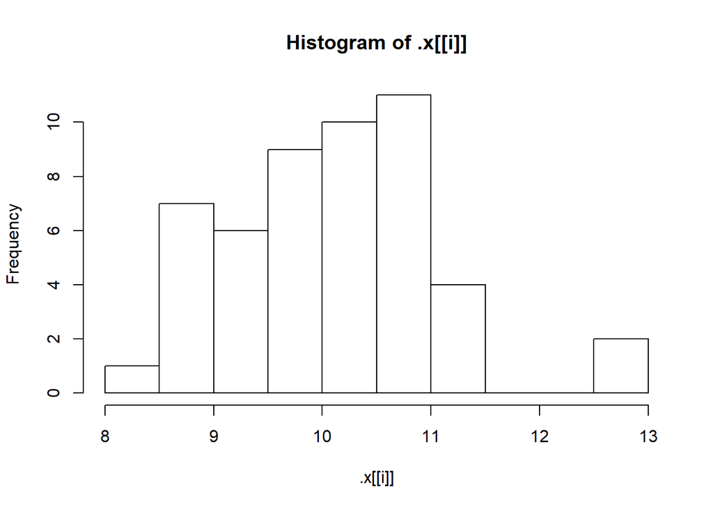

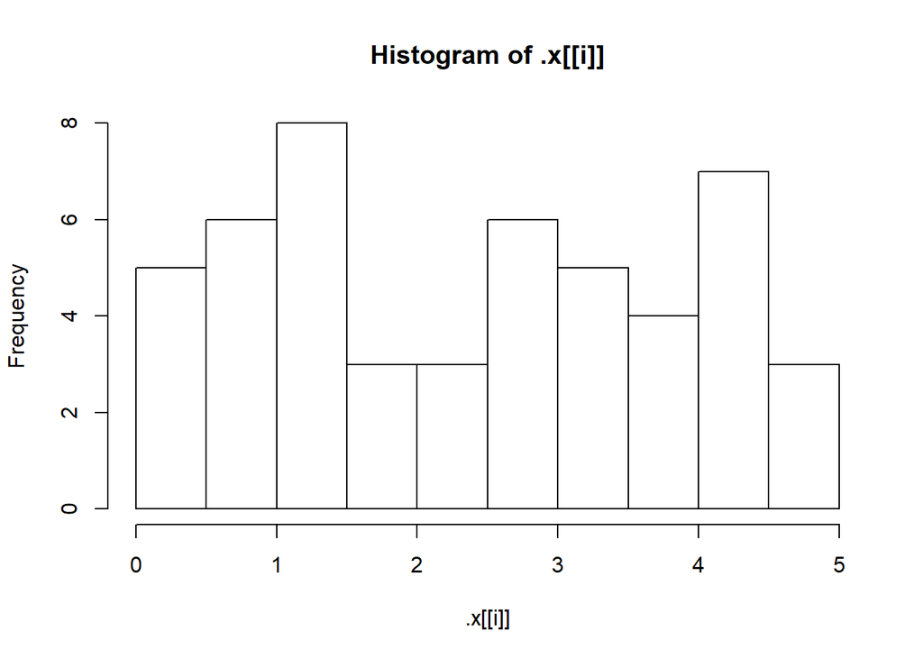

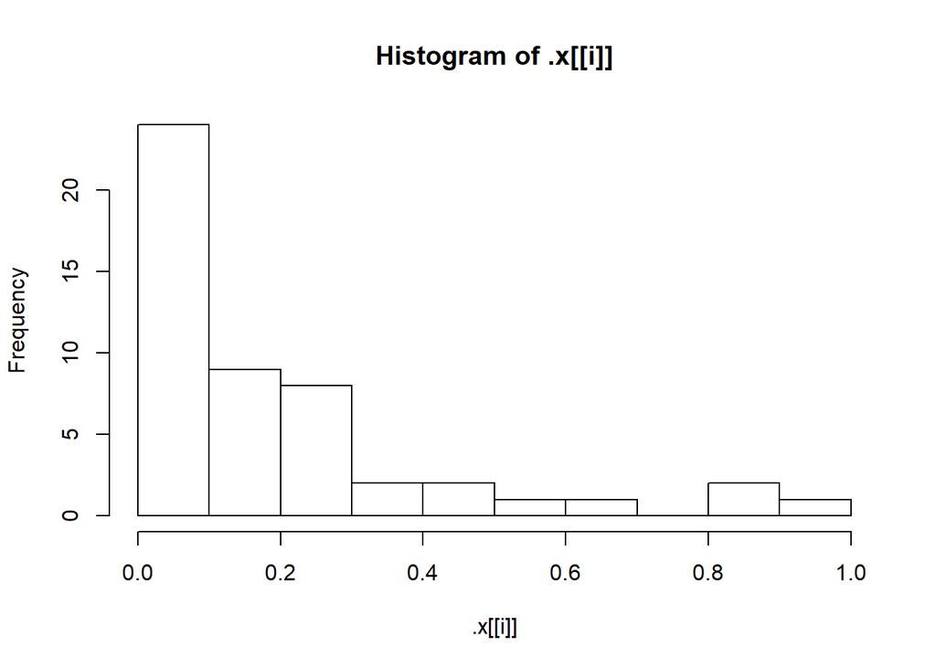

```r
# Define list of functions
f <- list(Normal = "rnorm", Uniform = "runif", Exp = "rexp")

# Define params
params <- list(
  Normal = list(mean = 10),
  Uniform = list(min = 0, max = 5),
  Exp = list(rate = 5)
)

# Assign the simulated samples to sims
sims <- invoke_map(f, params, n = 50)

# Use walk() to make a histogram of each element in sims
walk(sims, hist)
```

## Walking over two or more arguments

Those histograms were pretty good, but they really needed better breaks for the bins on the x-axis. That means we need to vary two arguments to `hist()`: `x` and `breaks`. Remember `map2()`? That allowed us to iterate over two arguments. Guess what? There is a `walk2()`, too!

Let’s use `walk2()` to improve those histograms with better breaks.

**INSTRUCTIONS**

We’ve loaded `sims` in your workspace.

The default value for the breaks argument to`hist()` is `"Sturges"`.

Replace `"Sturges"` in the `breaks_list` list with reasonable breaks for the histograms. Let’s use `seq(6, 16, 0.5)` for the Normal, `seq(0, 5, 0.25)` for the Uniform and `seq(0, 1.5, 0.1)` for the Exponential.

Use `walk2()` to create a histogram for each sample with the breaks in `breaks_list`.

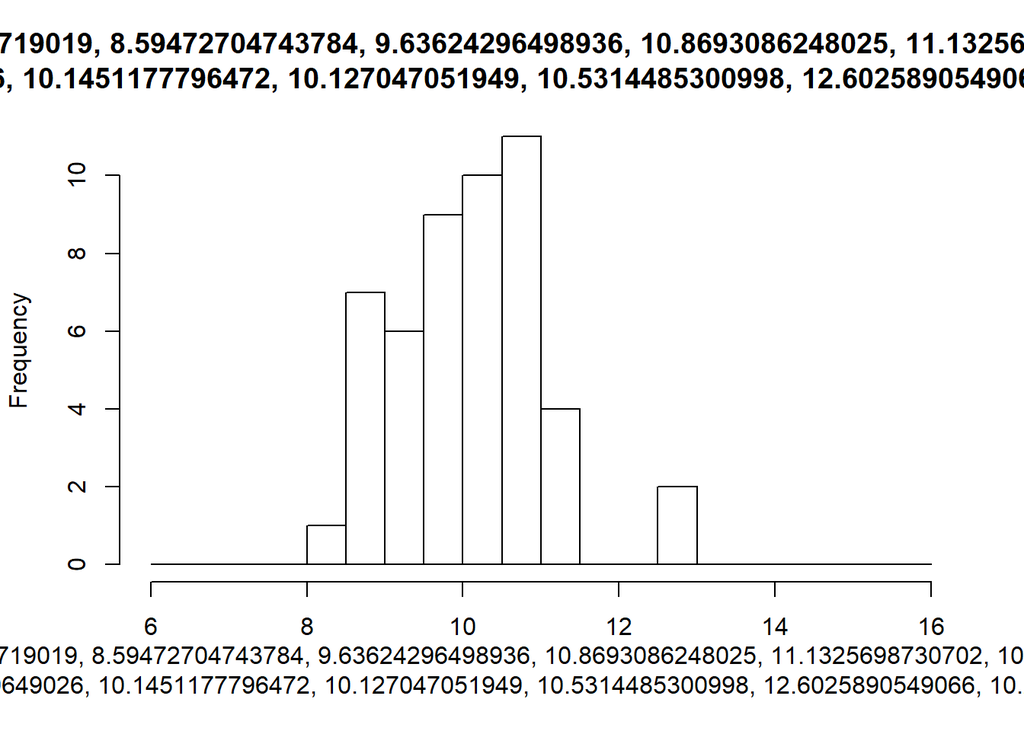

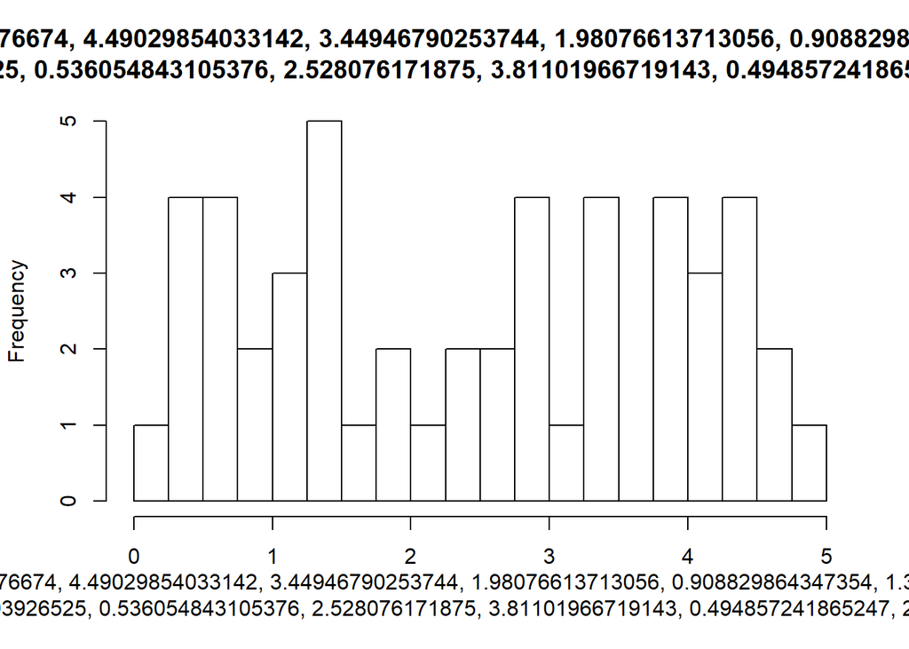

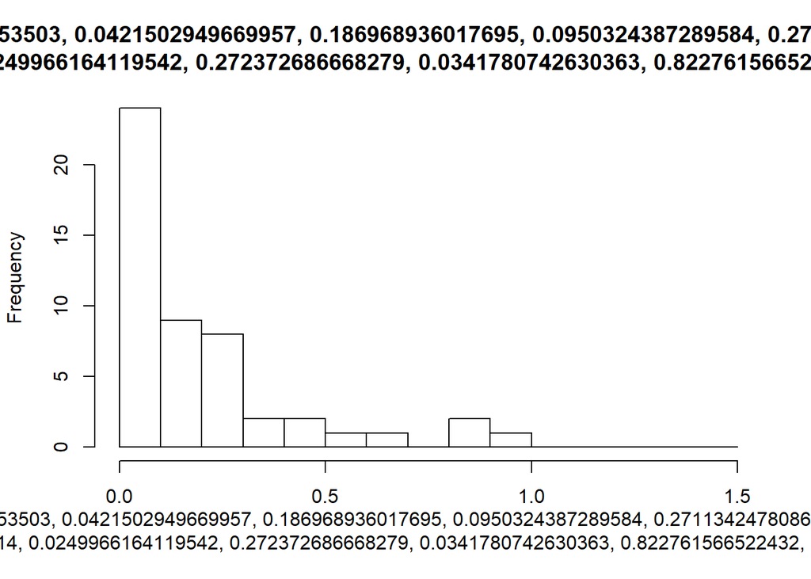

```r
# Replace "Sturges" with reasonable breaks for each sample
breaks_list <- list(
  Normal = seq(6, 16, 0.5),
  Uniform = seq(0, 5, 0.25),
  Exp = seq(0, 1.5, 0.1)
)

# Use walk2() to make histograms with the right breaks
walk2(sims, breaks_list, hist)
```

## Putting together writing functions and walk

In the previous exercise, we hard-coded the breaks, but that was a little lazy. Those breaks probably won’t be great if we change the parameters of our simulation.

A better idea would be to generate reasonable breaks based on the actual values in our simulated samples. This is a great chance to review our function writing skills and combine our own function with `purrr`.

Let’s start by writing our own function `find_breaks()`, which copies the default breaks in the `ggplot2` package: break the range of the data in 30 bins.

How do we start? Simple, of course! Here’s a snippet of code that works for the first sample:

```
rng <- range(sims[[1]], na.rm = TRUE)
seq(rng[1], rng[2], length.out = 30)
```

Your job in this exercise is to turn that snippet into a function.

In the next exercise, we’ll combine `find_breaks()` with `map()` and `walk2()` to create histograms with sensible breaks.

**INSTRUCTIONS**

Turn the snippet above into a function called `find_breaks()`, which takes a single argument `x` and return the sequence of breaks.

Check that your function works by calling `find_breaks()` on `sims[[1]]`.

```r
# Turn this snippet into find_breaks()
find_breaks <- function(x){
  rng <- range(x, na.rm = TRUE)
  seq(rng[1], rng[2], length.out = 30)
}

# Call find_breaks() on sims[[1]]
find_breaks(sims[[1]])
```

```
##  [1]  8.020265  8.181366  8.342467  8.503568  8.664668  8.825769  8.986870
##  [8]  9.147971  9.309072  9.470172  9.631273  9.792374  9.953475 10.114576
## [15] 10.275677 10.436777 10.597878 10.758979 10.920080 11.081181 11.242281
## [22] 11.403382 11.564483 11.725584 11.886685 12.047785 12.208886 12.369987
## [29] 12.531088 12.692189
```

## Nice breaks for all

Now that we have `find_breaks()`, we can find nice breaks for all the samples using `map()`. Then, pass the result into `walk2()` to get nice (but custom breaks) for our samples.

**INSTRUCTIONS**

Use `map()` to iterate `find_breaks()` over `sims` and assign the result to `nice_breaks`.

Use `nice_breaks` as the second argument to `walk2()` to iterate over both the simulations and calculated breaks to plot histograms.

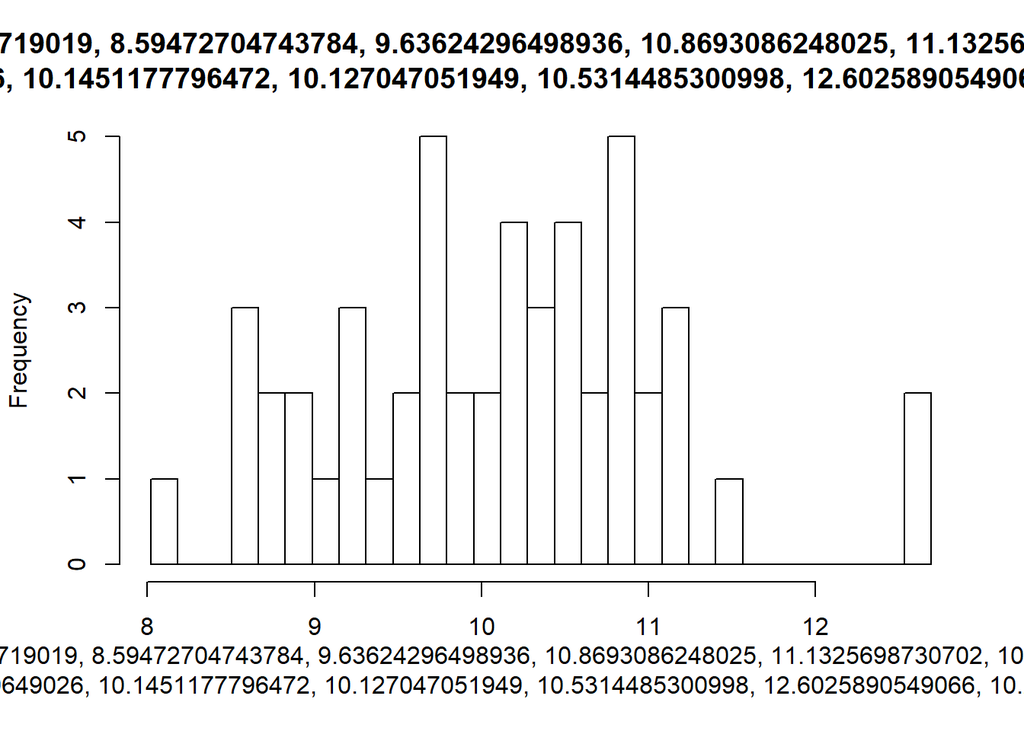

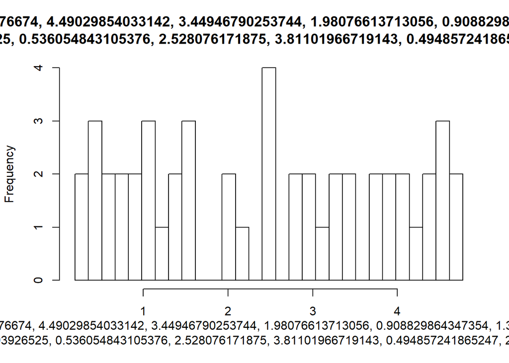

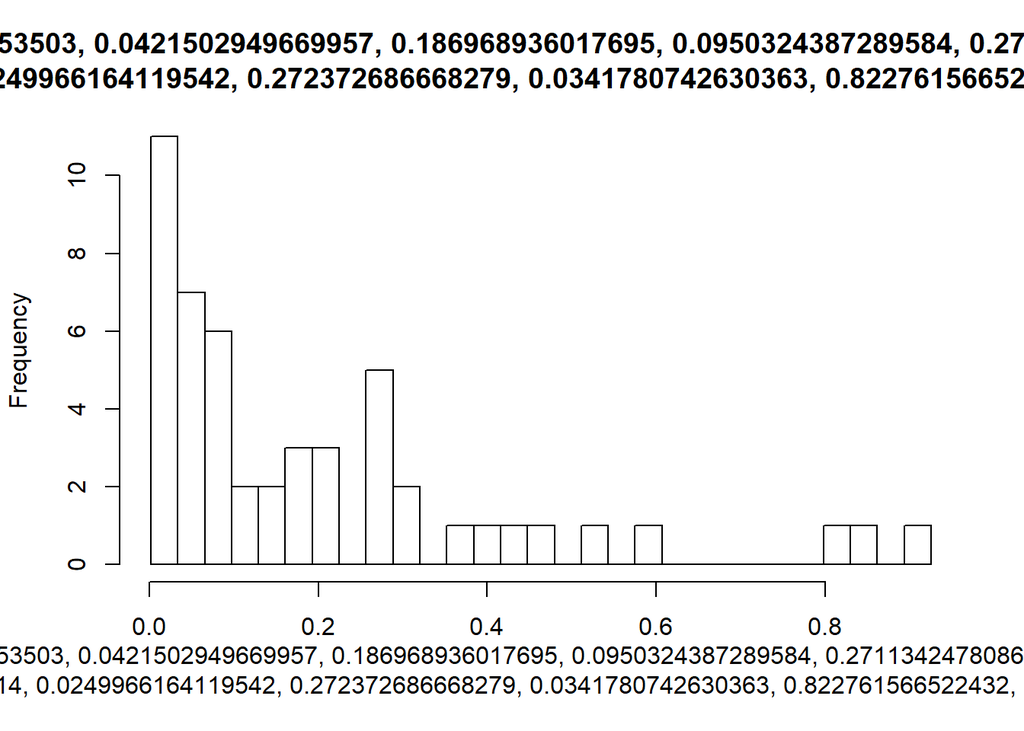

```r
# Use map() to iterate find_breaks() over sims: nice_breaks
nice_breaks <- map(sims, find_breaks)

# Use nice_breaks as the second argument to walk2()
walk2(sims, nice_breaks, hist)
```

## Walking with many arguments: pwalk

Ugh! Nice breaks but those plots had UUUUGLY labels and titles. The x-axis labels are easy to fix if we don’t mind every plot having its x-axis labeled the same way. We can use the `...` argument to any of the `map()` or `walk()` functions to pass in further arguments to the function `.f`. In this case, we might decide we don’t want any labels on the x-axis, in which case we need to pass an empty string to the xlab argument of `hist()`:

```
walk2(sims, nice_breaks, hist, xlab = "")
```

But, what about the titles? We don’t want them to be the same for each plot. How can we iterate over the arguments `x`, `breaks` and `main`? You guessed it, there is a `pwalk()` function that works just like `pmap()`.

Let’s use `pwalk()` to tidy up these plots. Also, let’s increase our sample size to 1000.

**INSTRUCTIONS**

Increase the sample size to 1000.

Create a vector `nice_titles` that contains the character strings: `"Normal(10, 1)"`, `"Uniform(0, 5)"` and `"Exp(5)"`.

Use `pwalk()` instead of `walk2()` to iterate over the `x`, `breaks` and `main` arguments to `hist()`. Like for `pmap()`, the first argument to `pwalk()` should be a `list()` of arguments to `hist()` using matching by name. Keep the `xlab = ""` argument as-is to keep things clean.

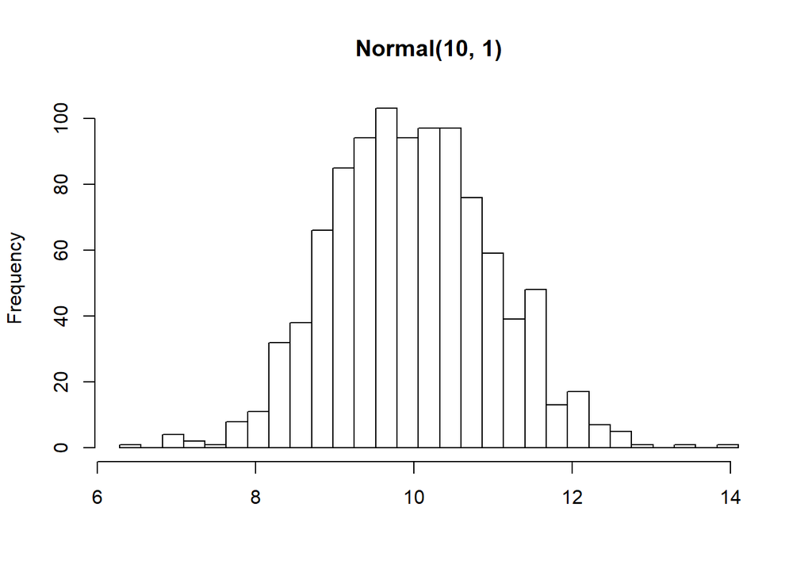

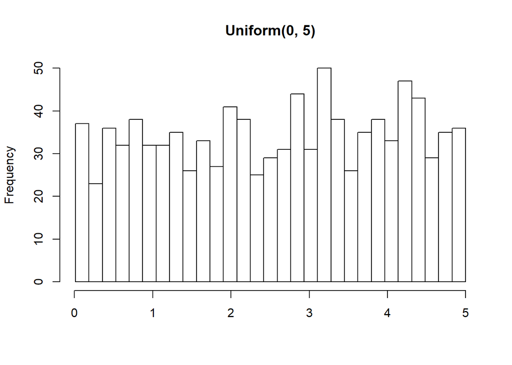

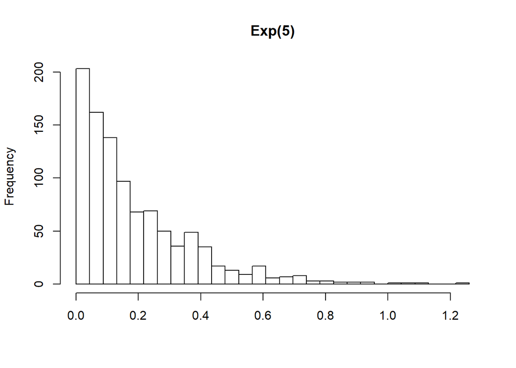

```r
# Increase sample size to 1000
sims <- invoke_map(f, params, n = 1000)

# Compute nice_breaks (don't change this)
nice_breaks <- map(sims, find_breaks)

# Create a vector nice_titles
nice_titles <- c("Normal(10, 1)", "Uniform(0, 5)", "Exp(5)")

# Use pwalk() instead of walk2()
pwalk(list(x = sims, breaks = nice_breaks, main = nice_titles), hist, xlab = "")
```

## Walking with pipes

One of the nice things about the `walk()` functions is that they return the object you passed to them. This means they can easily be used in pipelines (a pipeline is just a short way of saying “a statement with lots of pipes”).

To illustrate, we’ll return to our first example of making histograms for each sample:

```
walk(sims, hist)
```

Take a look at what gets returned:

```
tmp <- walk(sims, hist)
str(tmp)
```

It’s our original `sims` object. That means we can pipe the `sims` object along to other functions. For example, we might want some basic summary statistics on each sample as well as our histograms.

**INSTRUCTIONS**

We’ve converted `walk(sims, hist)` to a piped statement: `sims %>% walk(hist)`. Pipe the result into `map` using `summary()` as the `.f` argument.

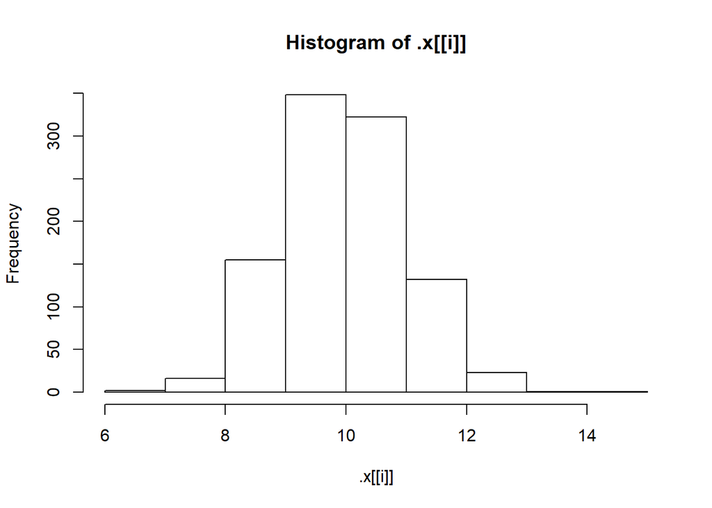

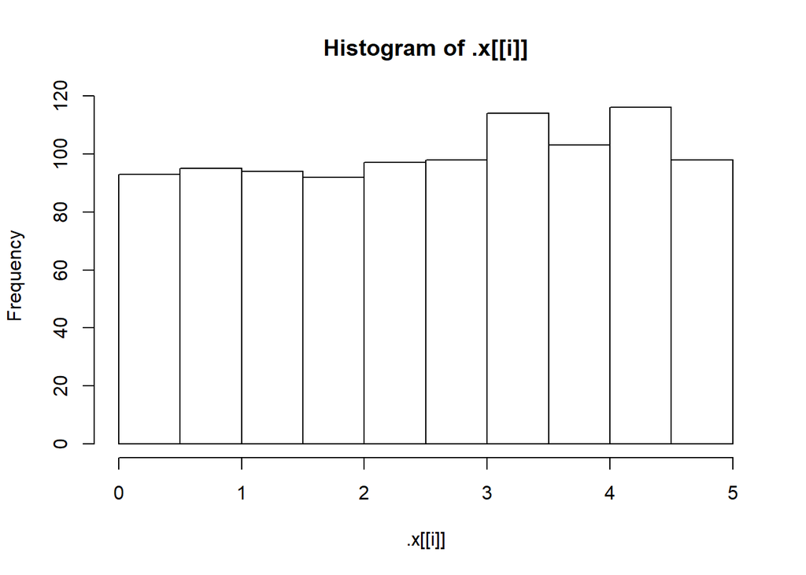

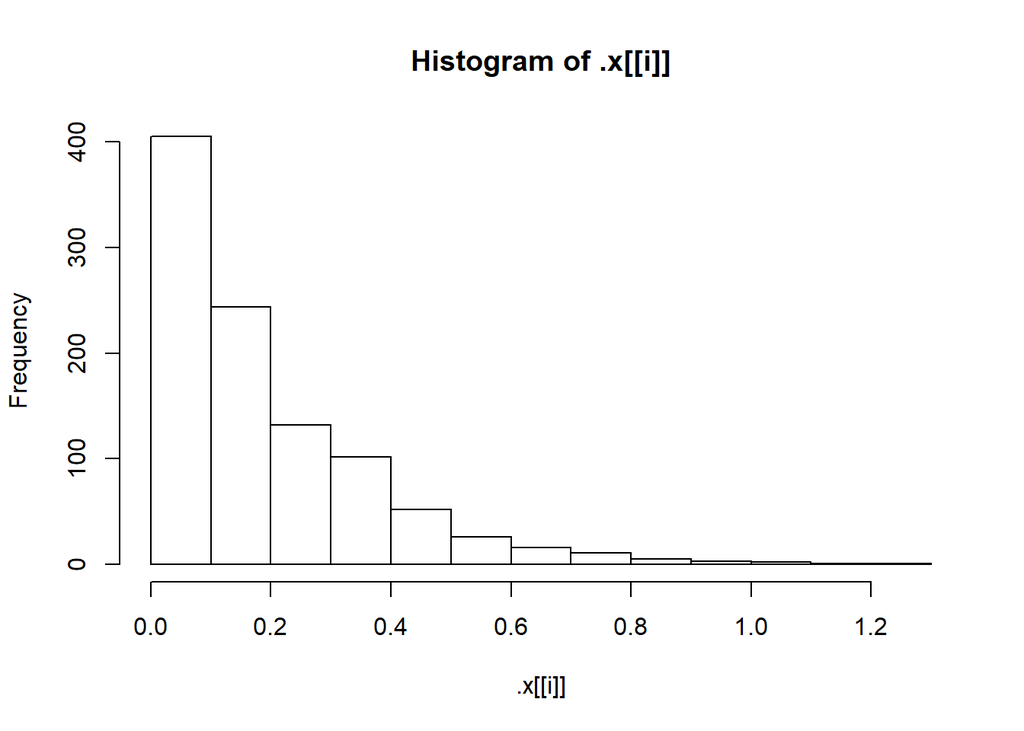

```
## $Normal
##    Min. 1st Qu.  Median    Mean 3rd Qu.    Max.
##   6.279   9.255   9.942   9.972  10.628  14.098
##
## $Uniform
##    Min. 1st Qu.  Median    Mean 3rd Qu.    Max.
## 0.01183 1.32275 2.66486 2.57597 3.83063 4.99713
##
## $Exp
##      Min.   1st Qu.    Median      Mean   3rd Qu.      Max.
## 0.0002445 0.0556391 0.1299581 0.1899873 0.2730859 1.2602801
```

```r
# Pipe this along to map(), using summary() as .f
sims %>%
  walk(hist) %>%
  map(summary)
```

# Chapter 5: Robust Functions

In this chapter we’ll focus on writing functions that don’t surprise you or your users. We’ll expose you to some functions that work 95% of the time, and 5% of the time fail in surprising ways. You’ll learn which functions you should avoid using inside a function and which you should use with care.

## An error is better than a surprise

Recall our `both_na()` function from Chapter 2, that finds the number of entries where vectors `x` and `y` both have missing values:

```
both_na <- function(x, y) {
  sum(is.na(x) & is.na(y))
}
```

We had an example where the behavior was a little surprising:

```
x <- c(NA, NA, NA)
y <- c( 1, NA, NA, NA)
both_na(x, y)
```

The function works and returns `3`, but we certainly didn’t design this function with the idea that people could pass in different length arguments.

Using `stopifnot()` is a quick way to have your function stop, if a condition isn’t meant. `stopifnot()` takes logical expressions as arguments and if any are `FALSE` an error will occur.

```r
# Define troublesome x and y
x <- c(NA, NA, NA)
y <- c( 1, NA, NA, NA)

both_na <- function(x, y) {
  # Add stopifnot() to check length of x and y
  stopifnot(length(x) == length(y))

  sum(is.na(x) & is.na(y))
}

# Call both_na() on x and y
both_na(x, y)
```

```
## Error: length(x) == length(y) is not TRUE
```

## An informative error is even better

Using `stop()` instead of `stopifnot()` allows you to specify a more informative error message. Recall the general pattern for using `stop()` is:

```
if (condition) {
  stop("Error", call. = FALSE)
}
```

Writing good error messages is an important part of writing a good function! We recommend your error tells the user what should be true, not what is false. For example, here a good error would be `"x and y must have the same length"`, rather than the bad error `"x and y don't have the same length"`.

Let’s use this pattern to write a better check for the length of `x` and `y`.

**INSTRUCTIONS**

Replace condition with a logical statement that evaluates to `TRUE` when `x` and `y` have different lengths.

Change the error message to `"x and y must have the same length"`.

Run the call to `both_na()` to verify it returns a more informative error

```r
# Define troublesome x and y
x <- c(NA, NA, NA)
y <- c( 1, NA, NA, NA)

both_na <- function(x, y) {
  # Replace condition with logical
  if (length(x) != length(y)) {
    # Replace "Error" with better message
    stop("x and y must have the same length", call. = FALSE)
  }

  sum(is.na(x) & is.na(y))
}

# Call both_na()
both_na(x, y)
```

```
## Error: x and y must have the same length
```

## A different kind of surprise: side effects

Side effects describe the things that happen when you run a function that alters the state of your R session. If `foo()` is a function with no side effects (a.k.a. pure), then when we run `x <- foo()`, the only change we expect is that the variable `x` now has a new value. No other variables in the global environment should be changed or created, no output should be printed, no plots displayed, no files saved, no options changed. We know exactly the changes to the state of the session just by reading the call to the function.

Can you identify which of these functions doesn’t have side effects?

```
show_missings <- function(x) {
  n <- sum(is.na(x))
  cat("Missing values: ", n, "\n", sep = "")
  x
}

replace_missings <- function(x, replacement) {
  x[is.na(x)] <- replacement
  x
}

plot_missings <- function(x) {
  plot(seq_along(x), is.na(x))
  x
}

exclude_missings <- function() {
  options(na.action = "na.exclude")
}
```

Possible Answers (Correct answer is **Bolded)

show_missings()

**replace_missings()**

plot_missings()

exclude_missings()

## sapply is another common culprit (for returning unstable types)

`sapply()` is another common offender returning unstable types. The type of output returned from `sapply()` depends on the type of input.

Consider the following data frame and two calls to `sapply()`:

```
df <- data.frame(
  a = 1L,
  b = 1.5,
  y = Sys.time(),
  z = ordered(1)
)

A <- sapply(df[1:4], class)
B <- sapply(df[3:4], class)
```

What type of objects will be `A` and `B` be?

Possible Answers (Correct Answer is **Bolded**)

A and B will both be character vectors.

A and B will both be lists.

A will be a list, B will be a character vector.

**A will be a list, B will be a character matrix.**

## Using purrr solves the problem

This unpredictable behaviour is a sign that you shouldn’t rely on `sapply()` inside your own functions.

So, what do you do? Use alternate functions that are type consistent! And you already know a whole set: the `map()` functions in `purrr`.

In this example, when we call `class()` on the columns of the data frame we are expecting character output, so our function of choice should be: `map_chr()`:

```
df <- data.frame(
  a = 1L,
  b = 1.5,
  y = Sys.time(),
  z = ordered(1)
)

A <- map_chr(df[1:4], class)
B <- map_chr(df[3:4], class)
```

Except that gives us errors. This is a good thing! It alerts us that our assumption (that `class()` would return purely character output) is wrong.

Let’s look at a couple of solutions. First, we could use `map()` instead of `map_chr()`. Our result will always be a list, no matter the input.

**INSTRUCTIONS**

Define `X`, `Y` and `Z` using `map()` instead of `sapply()`.

Call `str()` on your `X`, `Y` and `Z` to demonstrate type consistency of `map()`.

```r
# sapply calls
A <- sapply(df[1:4], class)
B <- sapply(df[3:4], class)
C <- sapply(df[1:2], class)

# Demonstrate type inconsistency
str(A)
```

```
##  Named chr [1:4] "numeric" "numeric" "numeric" "numeric"
##  - attr(*, "names")= chr [1:4] "a" "b" "c" "d"
```

```r
str(B)
```

```
##  Named chr [1:2] "numeric" "numeric"
##  - attr(*, "names")= chr [1:2] "c" "d"
```

```r
str(C)
```

```
##  Named chr [1:2] "numeric" "numeric"
##  - attr(*, "names")= chr [1:2] "a" "b"
```

```r
# Use map() to define X, Y and Z
X <- map(df[1:4], class)
Y <- map(df[3:4], class)
Z <- map(df[1:2], class)


# Use str() to check type consistency
str(X)
```

```
## List of 4
##  $ a: chr "numeric"
##  $ b: chr "numeric"
##  $ c: chr "numeric"
##  $ d: chr "numeric"
```

```r
str(Y)
```

```
## List of 2
##  $ c: chr "numeric"
##  $ d: chr "numeric"
```

```r
str(Z)
```

```
## List of 2
##  $ a: chr "numeric"
##  $ b: chr "numeric"
```

## A type consistent solution

If we wrap our solution into a function, we can be confident that this function will always return a list because we’ve used a type consistent function, `map()`:

```
col_classes <- function(df) {
  map(df, class)
}
```

But what if you wanted this function to always return a character string?

`One option would be to decide what should happen if class()` returns something longer than length 1. For example, we might simply take the first element of the vector returned by `class()`.

**INSTRUCTIONS**

Assign the body of our previous function to the variable `class_list`.

Use `map_chr()` along with the numeric subsetting shortcut, to extract the first element from every item in `class_list`.

Run the final three lines to verify our new function always returns a character vector.

```r
col_classes <- function(df) {
  # Assign list output to class_list
  class_list <- map(df, class)

  # Use map_chr() to extract first element in class_list
  map_chr(class_list, 1)
}

# Check that our new function is type consistent
df %>% col_classes() %>% str()
```

```
##  Named chr [1:4] "numeric" "numeric" "numeric" "numeric"
##  - attr(*, "names")= chr [1:4] "a" "b" "c" "d"
```

```r
df[3:4] %>% col_classes() %>% str()
```

```
##  Named chr [1:2] "numeric" "numeric"
##  - attr(*, "names")= chr [1:2] "c" "d"
```

```r
df[1:2] %>% col_classes() %>% str()
```

```
##  Named chr [1:2] "numeric" "numeric"
##  - attr(*, "names")= chr [1:2] "a" "b"
```

## Or fail early if something goes wrong

Another option would be to simply fail. We could rely on `map_chr()`’s type consistency to fail for us:

```
col_classes <- function(df) {
  map_chr(df, class)
}


df %>% col_classes() %>% str()
```

Or, check the condition ourselves and return an informative error message. We’ll implement this approach in this exercise.

As you write more functions, you’ll find you often come across this tension between implementing a function that does something sensible when something surprising happens, or simply fails when something surprising happens. Our recommendation is to fail when you are writing functions that you’ll use behind the scenes for programming and to do something sensible when writing functions for users to use interactively.

(And by the way, `flatten_chr()` is yet another useful function in `purrr`. It takes a list and removes its hierarchy. The suffix `_chr` indicates that this is another type consistent function, and will either return a character string or an error message.)

**INSTRUCTIONS**

Replace `condition` with a logical statement that uses `any()` and `map_dbl()` to check if any element in `class_list` has length greater than 1.

Run the final three lines to verify an informative error is thrown.

```r
col_classes <- function(df) {
  class_list <- map(df, class)

  # Add a check that no element of class_list has length > 1
  if (any(map_dbl(class_list, length) > 1)) {
    stop("Some columns have more than one class", call. = FALSE)
  }

  # Use flatten_chr() to return a character vector
  flatten_chr(class_list)
}

# Check that our new function is type consistent
df %>% col_classes() %>% str()
```

[output not shown]

```r
df[3:4] %>% col_classes() %>% str()
```

[output not shown]

```r
df[1:2] %>% col_classes() %>% str()
```

```
##  chr [1:2] "numeric" "numeric"
```

## Programming with NSE functions

Let’s take a look at a function that uses the non-standard evaluation (NSE) function `filter()` from the `dplyr` package:

```r
big_x <- function(df, threshold) {
  dplyr::filter(df, x > threshold)
}
```

This `big_x()` function attempts to return all rows in `df` where the `x` column exceeds a certain `threshold`. Let’s get a feel for how it might be used.

**INSTRUCTIONS**

We’ve placed `diamonds_sub`, a 20 row subset of the diamonds data from the `ggplot2` package in your workspace. Use `big_x()` to find all rows in `diamonds_sub` where the `x` column is greater than 7.

```r
# Use big_x() to find rows in diamonds_sub where x > 7
big_x(diamonds_sub, threshold = 7)
```

```
##   carat   cut color clarity depth table price     x    y    z
## 1  1.35 Ideal     G     VS1  60.9    54 10471 7.186 7.15 4.30
## 2  1.63 Ideal     F      I1  62.0    55  7229 7.570 7.50 4.68
```

## When things go wrong

Now, let’s see how this function might fail. There are two instances in which the non-standard evaluation of `filter()` could cause surprising results:

1. The `x` column doesn’t exist in `df`.
2. There is a `threshold` column in `df`.

Let’s illustrate these failures. In each case we’ll use `big_x()` in the same way as the previous exercise, so we should expect the same output. However, not only do we get unexpected outputs, there is no indication (i.e. error message) that lets us know something might have gone wrong.

**INSTRUCTIONS**

Create a variable `x` and give it the value 1.

Use `big_x()` to find all rows in `diamonds_sub` where the `x` column is greater than 7.

Create a `threshold` column in `diamonds_sub` with the value 100. Use `big_x()` to find all rows in `diamonds_sub` where the `x` column is greater than 7.

```r
# Remove the x column from diamonds
diamonds_sub$x <- NULL

# Create variable x with value 1
x <- 1


# Use big_x() to find rows in diamonds_sub where x > 7
big_x(diamonds_sub, 7)
```

```
## [1] carat   cut     color   clarity depth   table   price   y       z
## <0 rows> (or 0-length row.names)
```

```r
# Create a threshold column with value 100
diamonds_sub$threshold <- 100

# Use big_x() to find rows in diamonds_sub where x > 7
big_x(diamonds_sub, 7)
```

```
##  [1] carat     cut       color     clarity   depth     table     price
##  [8] y         z         threshold
## <0 rows> (or 0-length row.names)
```

## What to do?

To avoid the problems caused by non-standard evaluation functions, you could avoid using them. In our example, we could achieve the same results by using standard subsetting (i.e. `[]`) instead of`filter()`. For more insight into dealing with NSE and how to write your own non-standard evaluation functions, we recommend reading Hadley’s [vignette](http://rpubs.com/hadley/157957) on the topic. Also, programming with the NSE functions in `dplyr` will be easier in a future version.

If you do need to use non-standard evaluation functions, it’s up to you to provide protection against the problem cases. That means you need to know what the problem cases are, to check for them, and to fail explicitly.

To see what that might look like, let’s rewrite `big_x()`to fail for our problem cases.

**INSTRUCTIONS**

Write a check for each of the following:

If `x` is not in `names(df)`, stop with the message `"df must contain variable called x"`.

If threshold is in `names(df)`, stop with the message `"df must not contain variable called threshold"` .

Remember to use the argument `call. = FALSE` in each call to `stop()` so that the call is not a part of the error message.

```r
big_x <- function(df, threshold) {
  # Write a check for x not being in df
  if (!"x" %in% names(df)) {
    stop("df must contain variable called x", call. = FALSE)
  }



  # Write a check for threshold being in df
  if ("threshold" %in% names(df)) {
    stop("df must not contain variable called threshold", call. = FALSE)
  }


  dplyr::filter(df, x > threshold)
}
```

## A hidden dependence

A classic example of a hidden dependence is the `stringsAsFactors` argument to the `read.csv()` function (and a few other data frame functions.)

When you see the following code, you don’t know exactly what the result will be:

```
pools <- read.csv("swimming_pools.csv")
```

That’s because if the argument stringsAsFactors isn’t specified, it inherits its value from getOption(“stringsAsFactors”), a global option that a user may change.

Just to prove that this is the case, let’s illustrate the problem.

**INSTRUCTIONS**

Use `read.csv()` as above to read in `swimming_pools.csv` and save it to the variable `pools`.

Examine the structure of `pools` and notice how the columns Name and `Address` are factors.

Change the global `stringsAsFactors` option to `FALSE`: `options(stringsAsFactors = FALSE)`.

Use `read.csv()` as above to read in the same CSV file to the variable `pools2`.

Examine the structure of `pools2`, and notice how the columns `Name` and `Address` are now characters.

```r
# Read in the swimming_pools.csv to pools
pools <- read.csv("swimming_pools.csv")

# Examine the structure of pools
str(pools)
```

```
## 'data.frame':    20 obs. of  4 variables:
##  $ Name     : Factor w/ 20 levels "Acacia Ridge Leisure Centre",..: 1 2 3 4 5 6 19 7 8 9 ...
##  $ Address  : Factor w/ 20 levels "1 Fairlead Crescent, Manly",..: 5 20 18 10 9 11 6 15 12 17 ...
##  $ Latitude : num  -27.6 -27.6 -27.6 -27.5 -27.4 ...
##  $ Longitude: num  153 153 153 153 153 ...
```

```r
# Change the global stringsAsFactor option to FALSE
options(stringsAsFactors = FALSE)

# Read in the swimming_pools.csv to pools2
pools2 <- read.csv("swimming_pools.csv")

# Examine the structure of pools2
str(pools2)
```

```
## 'data.frame':    20 obs. of  4 variables:
##  $ Name     : chr  "Acacia Ridge Leisure Centre" "Bellbowrie Pool" "Carole Park" "Centenary Pool (inner City)" ...
##  $ Address  : chr  "1391 Beaudesert Road, Acacia Ridge" "Sugarwood Street, Bellbowrie" "Cnr Boundary Road and Waterford Road Wacol" "400 Gregory Terrace, Spring Hill" ...
##  $ Latitude : num  -27.6 -27.6 -27.6 -27.5 -27.4 ...
##  $ Longitude: num  153 153 153 153 153 ...
```

## Legitimate use of options

In general, you want to avoid having the return value of your own functions depend on any global options. That way, you and others can reason about your functions without needing to know the current state of the options.

It is, however, okay to have side effects of a function depend on global options. For example, the `print()` function uses `getOption("digits")` as the default for the `digits` argument. This gives users some control over how results are displayed, but doesn’t change the underlying computation.

Let’s take a look at an example function that uses a global default sensibly. The `print.lm()` function has the options digits with default `max(3, getOption("digits") - 3)`.

**INSTRUCTIONS**

We’ve fit a regression model of fuel efficiency on weight using the `mtcars` dataset.

Use `summary()`to take a look at the fitted regression model. Pay particular attention to number of decimal places reported.

Set the global digits option to 2: `options(digits = 2)`.

Take another look at the fitted model using `summary()`.

Notice the number of decimal places has changed, but there is no change to the underlying `fit` object.

```r
# Fit a regression model
fit <- lm(mpg ~ wt, data = mtcars)

# Look at the summary of the model
summary(fit)
```

```
##
## Call:
## lm(formula = mpg ~ wt, data = mtcars)
##
## Residuals:
##     Min      1Q  Median      3Q     Max
## -4.5432 -2.3647 -0.1252  1.4096  6.8727
##
## Coefficients:
##             Estimate Std. Error t value Pr(>|t|)
## (Intercept)  37.2851     1.8776  19.858  < 2e-16 ***
## wt           -5.3445     0.5591  -9.559 1.29e-10 ***
## ---
## Signif. codes:  0 '***' 0.001 '**' 0.01 '*' 0.05 '.' 0.1 ' ' 1
##
## Residual standard error: 3.046 on 30 degrees of freedom
## Multiple R-squared:  0.7528, Adjusted R-squared:  0.7446
## F-statistic: 91.38 on 1 and 30 DF,  p-value: 1.294e-10
```

```r
# Set the global digits option to 2
options(digits = 2)

# Take another look at the summary
summary(fit)
```

```
##
## Call:
## lm(formula = mpg ~ wt, data = mtcars)
##
## Residuals:
##    Min     1Q Median     3Q    Max
## -4.543 -2.365 -0.125  1.410  6.873
##
## Coefficients:
##             Estimate Std. Error t value Pr(>|t|)
## (Intercept)   37.285      1.878   19.86  < 2e-16 ***
## wt            -5.344      0.559   -9.56  1.3e-10 ***
## ---
## Signif. codes:  0 '***' 0.001 '**' 0.01 '*' 0.05 '.' 0.1 ' ' 1
##
## Residual standard error: 3 on 30 degrees of freedom
## Multiple R-squared:  0.753,  Adjusted R-squared:  0.745
## F-statistic: 91.4 on 1 and 30 DF,  p-value: 1.29e-10
```